# R Notebook

#Setup for Data Analysis

```r
# Dataset: Heart Failure Clinical Records


library(tidyverse)
library(e1071)      # For skewness calculations
library(corrr)      # For tidy correlation matrices
library(car)        # For VIF calculation via glm
library(gridExtra)  # For side-by-side ggplot arranging

#loading and cleaning data
df <- read_csv("heart_failure_data.csv")

# Overview of data types and dimensions
#cat("=== DATASET STRUCTURE ===\n")
#glimpse(df)

# Check for missing values across all columns
#missing_summary <- colSums(is.na(df))
#cat("\n=== MISSING VALUES PER VARIABLE ===\n")
#print(missing_summary)

# Encode categorical binary variables as factors for clarity
df_clean <- df %>%
  mutate(
    anaemia             = factor(anaemia, levels = c(0, 1), labels = c("No", "Yes")),
    diabetes            = factor(diabetes, levels = c(0, 1), labels = c("No", "Yes")),
    high_blood_pressure = factor(high_blood_pressure, levels = c(0, 1), labels = c("No", "Yes")),
    sex                 = factor(sex, levels = c(0, 1), labels = c("Female", "Male")),
    smoking             = factor(smoking, levels = c(0, 1), labels = c("No", "Yes")),
    DEATH_EVENT         = factor(DEATH_EVENT, levels = c(0, 1), labels = c("Survived", "Died"))
  )

#summary statistics
continuous_vars <- c("age", "creatinine_phosphokinase", "ejection_fraction",
                      "platelets", "serum_creatinine", "serum_sodium", "time")
library(dplyr)
library(tidyr)
library(moments)

summary_stats <- df_clean %>%
  dplyr::select(all_of(continuous_vars)) %>%
  pivot_longer(cols = everything(), names_to = "variable", values_to = "value") %>%
  group_by(variable) %>%
  dplyr::summarise(
    n        = sum(!is.na(value)),
    mean     = base::mean(value, na.rm = TRUE),
    sd       = stats::sd(value, na.rm = TRUE),
    median   = stats::median(value, na.rm = TRUE),
    IQR      = stats::IQR(value, na.rm = TRUE),
    min      = base::min(value, na.rm = TRUE),
    max      = base::max(value, na.rm = TRUE),
    skewness = moments::skewness(value, na.rm = TRUE),
    .groups  = "drop"
  ) %>%
  mutate(
    skew_label = case_when(
      abs(skewness) < 0.5 ~ "Fairly Symmetric",
      abs(skewness) >= 0.5 & abs(skewness) <= 1 ~ "Moderately Skewed",
      abs(skewness) > 1 ~ "Highly Skewed"
    )
  )

print(summary_stats)
```

```
# A tibble: 7 × 10
  variable                     n      mean       sd   median     IQR     min      max skewness skew_label
  <chr>                    <int>     <dbl>    <dbl>    <dbl>   <dbl>   <dbl>    <dbl>    <dbl> <chr>
1 age                        299     60.8     11.9      60      19      40       95      0.421 Fairly Symmetric
2 creatinine_phosphokinase   299    582.     970.      250     466.     23     7861      4.44  Highly Skewed
3 ejection_fraction          299     38.1     11.8      38      15      14       80      0.553 Moderately Skewed
4 platelets                  299 263358.   97804.   262000   91000   25100   850000      1.45  Highly Skewed
5 serum_creatinine           299      1.39     1.03      1.1     0.5     0.5      9.4    4.43  Highly Skewed
6 serum_sodium               299    137.       4.41    137       6     113      148     -1.04  Highly Skewed
7 time                       299    130.      77.6     115     130       4      285      0.127 Fairly Symmetric
```

#Box-Cox Transformations of Variables

```r
library(MASS)
library(dplyr)

# Function to compute Box-Cox transform for a single vector
apply_boxcox_vector <- function(x) {
  # Shift non-positive values if any exist
  shift <- if (min(x, na.rm = TRUE) <= 0) abs(min(x, na.rm = TRUE)) + 0.001 else 0
  x_pos <- x + shift

  # Find optimal lambda
  bc <- boxcox(x_pos ~ 1, plotit = FALSE)
  opt_lambda <- bc$x[which.max(bc$y)]

  # Apply transformation
  if (abs(opt_lambda) < 1e-4) {
    transformed <- log(x_pos)
  } else {
    transformed <- (x_pos^opt_lambda - 1) / opt_lambda
  }

  attr(transformed, "lambda") <- opt_lambda
  return(transformed)
}

# Apply to all continuous variables and create new transformed columns
df_boxcox_transformed <- df_clean %>%
  mutate(across(
    .cols = all_of(continuous_vars),
    .fns = apply_boxcox_vector,
    .names = "bc_{.col}"
  ))

# Print estimated lambdas
lambdas <- sapply(df_boxcox_transformed[paste0("bc_", continuous_vars)], function(col) attr(col, "lambda"))
print(lambdas)
```

```
                     bc_age bc_creatinine_phosphokinase        bc_ejection_fraction                bc_platelets
                        0.0                        -0.2                         0.3                         0.5
        bc_serum_creatinine             bc_serum_sodium                     bc_time
                       -1.0                         2.0                         0.6
```

```r
library(MASS)
library(dplyr)
library(purrr)

get_boxcox_ci <- function(x, conf_level = 0.95) {
  # Shift non-positive values if present
  shift <- if (min(x, na.rm = TRUE) <= 0) abs(min(x, na.rm = TRUE)) + 0.001 else 0
  x_pos <- x + shift

  # Compute profile log-likelihood
  bc <- boxcox(x_pos ~ 1, plotit = FALSE)

  # Point estimate (max log-likelihood)
  max_loglik <- max(bc$y)
  opt_lambda <- bc$x[which.max(bc$y)]

  # Chi-squared cutoff threshold for confidence interval
  limit <- max_loglik - 0.5 * qchisq(conf_level, df = 1)

  # Filter lambda values within cutoff
  ci_lambdas <- bc$x[bc$y >= limit]
  lambda_low  <- min(ci_lambdas)
  lambda_high <- max(ci_lambdas)

  return(tibble(
    lambda_hat = round(opt_lambda, 3),
    ci_lower   = round(lambda_low, 3),
    ci_upper   = round(lambda_high, 3),
    ci_95      = paste0("[", round(lambda_low, 2), ", ", round(lambda_high, 2), "]")
  ))
}

# Calculate CIs across all continuous variables
continuous_vars <- c("age", "creatinine_phosphokinase", "ejection_fraction",
                       "platelets", "serum_creatinine", "serum_sodium", "time")

ci_summary <- map_dfr(continuous_vars, ~ {
  get_boxcox_ci(df_clean[[.x]]) %>%
    mutate(variable = .x, .before = 1)
})

print(ci_summary)
```

```
# A tibble: 7 × 5
  variable                 lambda_hat ci_lower ci_upper ci_95
  <chr>                         <dbl>    <dbl>    <dbl> <chr>
1 age                             0       -0.5      0.5 [-0.5, 0.5]
2 creatinine_phosphokinase       -0.2     -0.2     -0.1 [-0.2, -0.1]
3 ejection_fraction               0.3      0.1      0.6 [0.1, 0.6]
4 platelets                       0.5      0.4      0.6 [0.4, 0.6]
5 serum_creatinine               -1       -1.2     -0.8 [-1.2, -0.8]
6 serum_sodium                    2        1.6      2   [1.6, 2]
7 time                            0.6      0.5      0.7 [0.5, 0.7]
```

#Applying the Box-Cox Recommended Transforms

```r
library(dplyr)

df_clean <- df %>%
  mutate(
    # Log transformation for age (\lambda \approx 0)
    log_age = log(age),

    # Power transform (-0.2) for creatinine phosphokinase
    cpk_pow_neg02 = creatinine_phosphokinase^(-0.2),

    # Cube root transformation (\lambda \approx 0.33) for ejection fraction
    ef_cbrt = ejection_fraction^(1/3),

    # Square root transformation (\lambda = 0.5) for platelets
    sqrt_platelets = sqrt(platelets),

    # Inverse / -1 power transformation (\lambda = -1) for serum creatinine
    inv_serum_creatinine = 1 / serum_creatinine,

    # Square transformation (\lambda = 2) for serum sodium
    sq_serum_sodium = serum_sodium^2,

    # Square root transformation (\lambda \approx 0.5) for follow-up time
    sqrt_time = sqrt(time)
  )

df_clean
```

| age | anaemia | creatinine_phosphokinase | diabetes | ejection_fraction | high_blood_pressure | platelets | serum_creatinine | serum_sodium | sex | smoking | time | DEATH_EVENT | log_age | cpk_pow_neg02 | ef_cbrt | sqrt_platelets | inv_serum_creatinine | sq_serum_sodium | sqrt_time |
| --- | --- | --- | --- | --- | --- | --- | --- | --- | --- | --- | --- | --- | --- | --- | --- | --- | --- | --- | --- |
| 75.000 | 0 | 582 | 0 | 20 | 1 | 265000 | 1.90 | 130 | 1 | 0 | 4 | 1 | 4.317488 | 0.2799081 | 2.714418 | 514.7815 | 0.5263158 | 16900 | 2.000000 |
| 55.000 | 0 | 7861 | 0 | 38 | 0 | 263358 | 1.10 | 136 | 1 | 0 | 6 | 1 | 4.007333 | 0.1663047 | 3.361975 | 513.1842 | 0.9090909 | 18496 | 2.449490 |
| 65.000 | 0 | 146 | 0 | 20 | 0 | 162000 | 1.30 | 129 | 1 | 1 | 7 | 1 | 4.174387 | 0.3690876 | 2.714418 | 402.4922 | 0.7692308 | 16641 | 2.645751 |
| 50.000 | 1 | 111 | 0 | 20 | 0 | 210000 | 1.90 | 137 | 1 | 0 | 7 | 1 | 3.912023 | 0.3898840 | 2.714418 | 458.2576 | 0.5263158 | 18769 | 2.645751 |
| 65.000 | 1 | 160 | 1 | 20 | 0 | 327000 | 2.70 | 116 | 0 | 0 | 8 | 1 | 4.174387 | 0.3623898 | 2.714418 | 571.8391 | 0.3703704 | 13456 | 2.828427 |
| 90.000 | 1 | 47 | 0 | 40 | 1 | 204000 | 2.10 | 132 | 1 | 1 | 8 | 1 | 4.499810 | 0.4629994 | 3.419952 | 451.6636 | 0.4761905 | 17424 | 2.828427 |
| 75.000 | 1 | 246 | 0 | 15 | 0 | 127000 | 1.20 | 137 | 1 | 0 | 10 | 1 | 4.317488 | 0.3325163 | 2.466212 | 356.3706 | 0.8333333 | 18769 | 3.162278 |
| 60.000 | 1 | 315 | 1 | 60 | 0 | 454000 | 1.10 | 131 | 1 | 1 | 10 | 1 | 4.094345 | 0.3164739 | 3.914868 | 673.7952 | 0.9090909 | 17161 | 3.162278 |
| 65.000 | 0 | 157 | 0 | 65 | 0 | 263358 | 1.50 | 138 | 0 | 0 | 10 | 1 | 4.174387 | 0.3637643 | 4.020726 | 513.1842 | 0.6666667 | 19044 | 3.162278 |
| 80.000 | 1 | 123 | 0 | 35 | 1 | 388000 | 9.40 | 133 | 1 | 1 | 10 | 1 | 4.382027 | 0.3819610 | 3.271066 | 622.8965 | 0.1063830 | 17689 | 3.162278 |

[output cut: 289 more lines]

```r
cont_vars <- c("log_age", "cpk_pow_neg02", "ef_cbrt", "sqrt_platelets", "inv_serum_creatinine", "sq_serum_sodium", "sqrt_time")
```

#Plots of Box-Cox Transformed Variables #Due to lack of changing shape of distribution age, serum sodium, and ejection fraction transformations are not kept

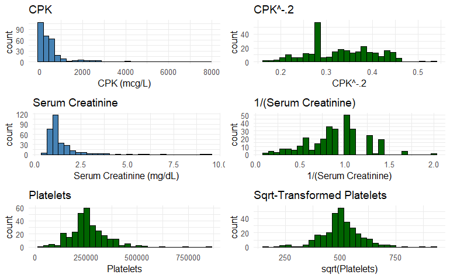

```r
# Visualizing Original vs. Transformed Distributions
p1 <- ggplot(df_clean, aes(x = creatinine_phosphokinase)) +
  geom_histogram(bins = 30, fill = "steelblue", color = "black") +
  theme_minimal() + labs(title = "CPK", x = "CPK (mcg/L)")

p2 <- ggplot(df_clean, aes(x = cpk_pow_neg02)) +
  geom_histogram(bins = 30, fill = "darkgreen", color = "black") +
  theme_minimal() + labs(title = "CPK^-.2", x = "CPK^-.2")

p3 <- ggplot(df_clean, aes(x = serum_creatinine)) +
  geom_histogram(bins = 30, fill = "steelblue", color = "black") +
  theme_minimal() + labs(title = "Serum Creatinine", x = "Serum Creatinine (mg/dL)")

p4 <- ggplot(df_clean, aes(x = inv_serum_creatinine)) +
  geom_histogram(bins = 30, fill = "darkgreen", color = "black") +
  theme_minimal() + labs(title = "1/(Serum Creatinine)", x = "1/(Serum Creatinine)")

p5 <- ggplot(df_clean, aes(x = platelets)) +
  geom_histogram(bins = 30, fill = "darkgreen", color = "black") +
  theme_minimal() + labs(title = "Platelets", x = "Platelets")

p6 <- ggplot(df_clean, aes(x = sqrt_platelets)) +
  geom_histogram(bins = 30, fill = "darkgreen", color = "black") +
  theme_minimal() + labs(title = "Sqrt-Transformed Platelets", x = "sqrt(Platelets)")

p7 <- ggplot(df_clean, aes(x = ejection_fraction)) +
  geom_histogram(bins = 30, fill = "darkgreen", color = "black") +
  theme_minimal() + labs(title = "Ejection Fraction", x = "Ejection Fraction")

p8 <- ggplot(df_clean, aes(x = ef_cbrt)) +
  geom_histogram(bins = 30, fill = "darkgreen", color = "black") +
  theme_minimal() + labs(title = "Cube Root EF", x = "Cube Root EF")

p9 <- ggplot(df_clean, aes(x = serum_sodium)) +
  geom_histogram(bins = 30, fill = "darkgreen", color = "black") +
  theme_minimal() + labs(title = "Serum Sodium", x = "Serum Sodium")

p10 <- ggplot(df_clean, aes(x = sq_serum_sodium)) +
  geom_histogram(bins = 30, fill = "darkgreen", color = "black") +
  theme_minimal() + labs(title = "Sqrt Serum Sodium", x = "Sqrt Serum Sodium")

p11 <- ggplot(df_clean, aes(x = age)) +
  geom_histogram(bins = 30, fill = "darkgreen", color = "black") +
  theme_minimal() + labs(title = "Age", x = "Age")

p12 <- ggplot(df_clean, aes(x = log_age)) +
  geom_histogram(bins = 30, fill = "darkgreen", color = "black") +
  theme_minimal() + labs(title = "Log Age", x = "log(Age)")

p13 <- ggplot(df_clean, aes(x = time)) +
  geom_histogram(bins = 30, fill = "darkgreen", color = "black") +
  theme_minimal() + labs(title = "Time", x = "Time")


p14 <- ggplot(df_clean, aes(x = sqrt_time)) +
  geom_histogram(bins = 30, fill = "darkgreen", color = "black") +
  theme_minimal() + labs(title = "Sqrt Time", x = "Time")

grid.arrange(p1, p2, p3, p4, p5, p6, ncol = 2)
```

[figure not shown]

```r
grid.arrange(p7, p8, p9, p10, p11, p12, p13, p14, ncol = 2)
```

```r
continuous_vars <- c("age", "cpk_pow_neg02",  "ejection_fraction",
                      "sqrt_platelets","inv_serum_creatinine", "serum_sodium", "sqrt_time")
binary_variables <- c("anaemia", "diabetes", "high_blood_pressure", "smoking")
```

#Outlier Detection From the Original to Box-Cox Transformed Variables

```r
library(dplyr)
library(tidyr)
library(purrr)

# Define feature sets
orig_vars <- c("age", "creatinine_phosphokinase", "ejection_fraction",
               "platelets", "serum_creatinine", "serum_sodium", "time")

bc_vars   <- c("age", "cpk_pow_neg02", "ejection_fraction",
               "sqrt_platelets", "inv_serum_creatinine", "serum_sodium", "sqrt_time")

# Helper function to calculate outlier diagnostics for a single vector
get_outlier_stats <- function(x, var_name, var_type) {
  x_clean <- x[!is.na(x)]
  n_total <- length(x_clean)

  # IQR Bounds (Tukey's Fences)
  q25 <- stats::quantile(x_clean, 0.25)
  q75 <- stats::quantile(x_clean, 0.75)
  iqr_val <- q75 - q25

  iqr_lower_1.5 <- q25 - 1.5 * iqr_val
  iqr_upper_1.5 <- q75 + 1.5 * iqr_val
  iqr_lower_3.0 <- q25 - 3.0 * iqr_val
  iqr_upper_3.0 <- q75 + 3.0 * iqr_val

  n_iqr_1.5 <- sum(x_clean < iqr_lower_1.5 | x_clean > iqr_upper_1.5)
  n_iqr_3.0 <- sum(x_clean < iqr_lower_3.0 | x_clean > iqr_upper_3.0)

  # Z-Score Bounds (|Z| > 3)
  mean_val <- base::mean(x_clean)
  sd_val   <- stats::sd(x_clean)
  z_scores <- (x_clean - mean_val) / sd_val
  n_z3     <- sum(abs(z_scores) > 3)

  tibble::tibble(
    type             = var_type,
    variable         = var_name,
    n_obs            = n_total,
    iqr_outliers_1.5 = n_iqr_1.5,
    pct_iqr_1.5      = round((n_iqr_1.5 / n_total) * 100, 2),
    iqr_outliers_3.0 = n_iqr_3.0,
    pct_iqr_3.0      = round((n_iqr_3.0 / n_total) * 100, 2),
    z_outliers_3     = n_z3,
    pct_z_3          = round((n_z3 / n_total) * 100, 2)
  )
}

# Run diagnostics on original variables
orig_diagnostics <- purrr::map_dfr(orig_vars, ~ get_outlier_stats(df_clean[[.x]], .x, "Original"))

# Run diagnostics on Box-Cox transformed variables
bc_diagnostics   <- purrr::map_dfr(bc_vars, ~ get_outlier_stats(df_clean[[.x]], .x, "Box-Cox Transformed"))

# Combine results into a comparison table
outlier_summary <- dplyr::bind_rows(orig_diagnostics, bc_diagnostics)

cat("=== OUTLIER DIAGNOSTICS COMPARISON ===\n")
```

```
=== OUTLIER DIAGNOSTICS COMPARISON ===
```

```r
print(outlier_summary, n = 20)
```

```
# A tibble: 14 × 9
   type                variable                 n_obs iqr_outliers_1.5 pct_iqr_1.5 iqr_outliers_3.0 pct_iqr_3.0 z_outliers_3 pct_z_3
   <chr>               <chr>                    <int>            <int>       <dbl>            <int>       <dbl>        <int>   <dbl>
 1 Original            age                        299                0        0                   0        0               0    0
 2 Original            creatinine_phosphokinase   299               29        9.7                18        6.02            7    2.34
 3 Original            ejection_fraction          299                2        0.67                0        0               1    0.33
 4 Original            platelets                  299               21        7.02                3        1               3    1
 5 Original            serum_creatinine           299               29        9.7                17        5.69            6    2.01
 6 Original            serum_sodium               299                4        1.34                1        0.33            3    1
 7 Original            time                       299                0        0                   0        0               0    0
 8 Box-Cox Transformed age                        299                0        0                   0        0               0    0
 9 Box-Cox Transformed cpk_pow_neg02              299                0        0                   0        0               0    0
10 Box-Cox Transformed ejection_fraction          299                2        0.67                0        0               1    0.33
11 Box-Cox Transformed sqrt_platelets             299               18        6.02                3        1               5    1.67
12 Box-Cox Transformed inv_serum_creatinine       299                3        1                   0        0               1    0.33
13 Box-Cox Transformed serum_sodium               299                4        1.34                1        0.33            3    1
14 Box-Cox Transformed sqrt_time                  299                0        0                   0        0               0    0
```

```r
# Side-by-side comparison for corresponding variables
comparison_table <- tibble::tibble(
  metric                   = c("CPK", "Serum Creatinine", "Platelets", "Time"),
  Original_Variable        = c("creatinine_phosphokinase", "serum_creatinine", "platelets", "time"),
  BoxCox_Variable          = c("cpk_pow_neg02", "inv_serum_creatinine", "sqrt_platelets", "sqrt_time")
) %>%
  dplyr::inner_join(orig_diagnostics %>% dplyr::select(Original_Variable = variable, Orig_IQR_1.5 = iqr_outliers_1.5, Orig_Z3 = z_outliers_3), by = "Original_Variable") %>%
  dplyr::inner_join(bc_diagnostics %>% dplyr::select(BoxCox_Variable = variable, BC_IQR_1.5 = iqr_outliers_1.5, BC_Z3 = z_outliers_3), by = "BoxCox_Variable")

print(comparison_table)
```

```
# A tibble: 4 × 7
  metric           Original_Variable        BoxCox_Variable      Orig_IQR_1.5 Orig_Z3 BC_IQR_1.5 BC_Z3
  <chr>            <chr>                    <chr>                       <int>   <int>      <int> <int>
1 CPK              creatinine_phosphokinase cpk_pow_neg02                  29       7          0     0
2 Serum Creatinine serum_creatinine         inv_serum_creatinine           29       6          3     1
3 Platelets        platelets                sqrt_platelets                 21       3         18     5
4 Time             time                     sqrt_time                       0       0          0     0
```

#Table Summarizing Variables Across Both Dead/Surviving Patients

```r
library(dplyr)
library(tidyr)
library(purrr)


#continuous variables summary by death event
cont_summary <- df_clean %>%
  dplyr::select(DEATH_EVENT, all_of(continuous_vars)) %>%
  pivot_longer(cols = all_of(continuous_vars), names_to = "variable", values_to = "value") %>%
  group_by(DEATH_EVENT, variable) %>%
  dplyr::summarise(
    n             = sum(!is.na(value)),
    mean          = base::mean(value, na.rm = TRUE),
    sd            = stats::sd(value, na.rm = TRUE),
    median        = stats::median(value, na.rm = TRUE),
    # Parametric 95% CI for the Mean
    mean_ci_lower = mean - 1.96 * (sd / sqrt(n)),
    mean_ci_upper = mean + 1.96 * (sd / sqrt(n)),
    # Empirical 95% Percentile Bounds (2.5th and 97.5th percentiles of sample)
    emp_p2.5      = stats::quantile(value, probs = 0.025, na.rm = TRUE),
    emp_p97.5     = stats::quantile(value, probs = 0.975, na.rm = TRUE),
    .groups       = "drop"
  ) %>%
  mutate(
    mean_sd   = sprintf("%.2f (%.2f)", mean, sd),
    mean_95ci = sprintf("[%.2f, %.2f]", mean_ci_lower, mean_ci_upper),
    emp_95ci  = sprintf("[%.2f, %.2f]", emp_p2.5, emp_p97.5)
  )

#reshape into table
cont_table_formatted <- cont_summary %>%
  dplyr::select(variable, DEATH_EVENT, mean_sd, median, mean_95ci, emp_95ci) %>%
  pivot_wider(
    names_from  = DEATH_EVENT,
    values_from = c(mean_sd, median, mean_95ci, emp_95ci)
  )


binary_vars <- binary_variables
#binary variable summary by death event
binary_summary <- df_clean %>%
  dplyr::select(DEATH_EVENT, dplyr::all_of(binary_vars)) %>%
  tidyr::pivot_longer(
    cols      = dplyr::all_of(binary_vars),
    names_to  = "variable",
    values_to = "value"
  ) %>%
  dplyr::group_by(DEATH_EVENT, variable) %>%
  dplyr::summarise(
    total_group = dplyr::n(),
    count_yes   = base::sum(value == "Yes" | value == 1, na.rm = TRUE),
    pct_yes     = (count_yes / total_group) * 100,
    .groups     = "drop"
  ) %>%
  dplyr::mutate(
    pct_label = base::sprintf("%.1f%% (%d/%d)", pct_yes, count_yes, total_group)
  ) %>%
  dplyr::select(variable, DEATH_EVENT, pct_label) %>%
  tidyr::pivot_wider(
    names_from  = DEATH_EVENT,
    values_from = pct_label
  )

cat("\n=== BINARY VARIABLES PREVALENCE (% YES) BY SURVIVAL STATUS ===\n")
```

```
=== BINARY VARIABLES PREVALENCE (% YES) BY SURVIVAL STATUS ===
```

```r
print(binary_summary)
```

```
# A tibble: 4 × 3
  variable            `0`            `1`
  <chr>               <chr>          <chr>
1 anaemia             40.9% (83/203) 47.9% (46/96)
2 diabetes            41.9% (85/203) 41.7% (40/96)
3 high_blood_pressure 32.5% (66/203) 40.6% (39/96)
4 smoking             32.5% (66/203) 31.2% (30/96)
```

```r
#reshape into table
cont_table_clean <- cont_summary %>%   dplyr::select(variable, DEATH_EVENT, mean_sd, median, emp_95ci) %>%
  tidyr::pivot_wider(
    names_from  = DEATH_EVENT,
    values_from = c(mean_sd, median, emp_95ci),
    names_glue  = "Group_{DEATH_EVENT}_{.value}"
  ) %>%
  dplyr::select(
    variable,
    Survived_Mean_SD = Group_0_mean_sd,
    Survived_Median  = Group_0_median,
    Survived_95CI    = Group_0_emp_95ci,
    Died_Mean_SD     = Group_1_mean_sd,
    Died_Median      = Group_1_median,
    Died_95CI        = Group_1_emp_95ci
  )

print(cont_table_clean)
```

```
# A tibble: 7 × 7
  variable             Survived_Mean_SD Survived_Median Survived_95CI    Died_Mean_SD   Died_Median Died_95CI
  <chr>                <chr>                      <dbl> <chr>            <chr>                <dbl> <chr>
1 age                  58.76 (10.64)             60     [40.00, 80.00]   65.22 (13.21)       65     [45.00, 92.50]
2 cpk_pow_neg02        0.33 (0.07)                0.333 [0.21, 0.45]     0.33 (0.07)          0.329 [0.18, 0.45]
3 ejection_fraction    40.27 (10.86)             38     [25.00, 60.00]   33.47 (12.53)       30     [15.75, 61.25]
4 inv_serum_creatinine 0.97 (0.29)                1     [0.32, 1.43]     0.72 (0.31)          0.769 [0.16, 1.36]
5 serum_sodium         137.22 (3.98)            137     [130.00, 145.00] 135.38 (5.00)      136.    [125.12, 145.00]
6 sqrt_platelets       508.43 (90.51)           513.    [356.58, 709.11] 496.52 (99.77)     508.    [268.06, 677.03]
7 sqrt_time            12.25 (2.89)              13.1   [5.82, 16.41]    7.61 (3.61)          6.67  [2.65, 14.54]
```

#Correlation Plots #All pairwise correlation is pretty low

```r
library(dplyr)

# Define baseline continuous predictors (excluding follow-up time to prevent leakage)
cont_vars_model <- c("age", "cpk_pow_neg02", "ejection_fraction",
                     "sqrt_platelets", "inv_serum_creatinine", "serum_sodium")

# Subset df_clean for continuous correlation analysis
df_cont <- df_clean %>%
  dplyr::select(dplyr::all_of(cont_vars_model))

library(corrr)

# Compute Pearson (linear) and Spearman (rank) correlations
pearson_mat  <- cor(df_cont, use = "pairwise.complete.obs", method = "pearson")
spearman_mat <- cor(df_cont, use = "pairwise.complete.obs", method = "spearman")

cat("=== PEARSON CORRELATION MATRIX ===\n")
```

```
=== PEARSON CORRELATION MATRIX ===
```

```r
print(round(pearson_mat, 3))
```

```
                        age cpk_pow_neg02 ejection_fraction sqrt_platelets inv_serum_creatinine serum_sodium
age                   1.000         0.097             0.060         -0.051               -0.257       -0.046
cpk_pow_neg02         0.097         1.000             0.076         -0.012               -0.063       -0.014
ejection_fraction     0.060         0.076             1.000          0.070                0.137        0.176
sqrt_platelets       -0.051        -0.012             0.070          1.000                0.061        0.056
inv_serum_creatinine -0.257        -0.063             0.137          0.061                1.000        0.254
serum_sodium         -0.046        -0.014             0.176          0.056                0.254        1.000
```

```r
cat("\n=== SPEARMAN CORRELATION MATRIX ===\n")
```

```
=== SPEARMAN CORRELATION MATRIX ===
```

```r
print(round(spearman_mat, 3))
```

```
                        age cpk_pow_neg02 ejection_fraction sqrt_platelets inv_serum_creatinine serum_sodium
age                   1.000         0.093             0.074         -0.052               -0.271       -0.102
cpk_pow_neg02         0.093         1.000             0.068         -0.060               -0.050       -0.017
ejection_fraction     0.074         0.068             1.000          0.054                0.178        0.162
sqrt_platelets       -0.052        -0.060             0.054          1.000                0.051        0.049
inv_serum_creatinine -0.271        -0.050             0.178          0.051                1.000        0.300
serum_sodium         -0.102        -0.017             0.162          0.049                0.300        1.000
```

```r
library(corrplot)

# Create copies of the correlation matrices with shortened variable names
pearson_short  <- pearson_mat
spearman_short <- spearman_mat

# Define clean, shortened labels
short_labels <- c("Age", "T(CPK)", "EF", "T(Platelets)", "T(SC)", "Sodium")

colnames(pearson_short)  <- short_labels
rownames(pearson_short)  <- short_labels
colnames(spearman_short) <- short_labels
rownames(spearman_short) <- short_labels

# Plot clean, side-by-side heatmaps
par(mfrow = c(1, 2))

corrplot(
  pearson_short,
  method       = "color",
  type         = "upper",
  addCoef.col  = "black",
  number.cex   = 0.85,
  tl.col       = "black",
  tl.srt       = 45,
  tl.cex       = 0.9,
  title        = "Pearson Correlation",
  mar          = c(0, 0, 2, 0)
)

corrplot(
  spearman_short,
  method       = "color",
  type         = "upper",
  addCoef.col  = "black",
  number.cex   = 0.85,
  tl.col       = "black",
  tl.srt       = 45,
  tl.cex       = 0.9,
  title        = "Spearman Correlation",
  mar          = c(0, 0, 2, 0)
)
```

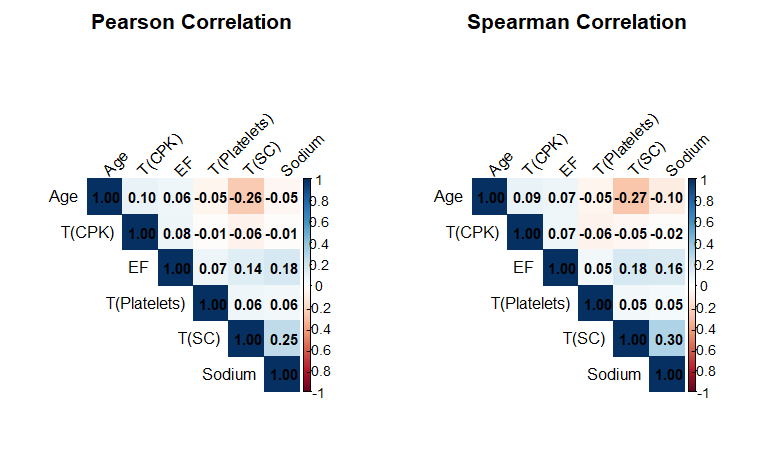

```r
par(mfrow = c(1, 1))
```

#Variance Inflation Factor Diagnostics #No high variation inflation for any predictor

```r
library(car)

# Define binary predictors
binary_vars <- c("anaemia", "diabetes", "high_blood_pressure", "smoking")

# Fit baseline logistic regression model including all continuous and binary predictors
formula_vif <- as.formula(
  paste("DEATH_EVENT ~", paste(c(cont_vars_model, binary_vars), collapse = " + "))
)

model_vif <- glm(formula_vif, data = df_clean, family = binomial)

# Compute VIF
vif_values <- car::vif(model_vif)

vif_summary <- tibble::tibble(
  predictor = names(vif_values),
  VIF       = as.numeric(vif_values)
) %>%
  dplyr::mutate(
    multicollinearity = dplyr::case_when(
      VIF < 5 ~ "Low (Acceptable)",
      VIF >= 5 & VIF < 10 ~ "Moderate",
      VIF >= 10 ~ "High (Severe)"
    )
  ) %>%
  dplyr::arrange(dplyr::desc(VIF))

cat("=== VARIANCE INFLATION FACTOR (VIF) DIAGNOSTICS ===\n")
```

```
=== VARIANCE INFLATION FACTOR (VIF) DIAGNOSTICS ===
```

```r
print(vif_summary)
```

```
# A tibble: 10 × 3
   predictor              VIF multicollinearity
   <chr>                <dbl> <chr>
 1 inv_serum_creatinine  1.13 Low (Acceptable)
 2 cpk_pow_neg02         1.12 Low (Acceptable)
 3 anaemia               1.11 Low (Acceptable)
 4 age                   1.10 Low (Acceptable)
 5 serum_sodium          1.09 Low (Acceptable)
 6 ejection_fraction     1.07 Low (Acceptable)
 7 high_blood_pressure   1.06 Low (Acceptable)
 8 diabetes              1.05 Low (Acceptable)
 9 smoking               1.04 Low (Acceptable)
10 sqrt_platelets        1.02 Low (Acceptable)
```

#Scaling Variables + Perform PCA

```r
library(dplyr)

#continuous variables in the model
cont_vars_model <- c("age", "cpk_pow_neg02", "ejection_fraction",
                     "sqrt_platelets", "inv_serum_creatinine", "serum_sodium")

#perform PCA
x_mat <- df_clean %>%
  dplyr::select(dplyr::all_of(cont_vars_model))

pca_res <- prcomp(x_mat, center = TRUE, scale. = TRUE)

# 3. Variance Explained Summary
var_explained <- pca_res$sdev^2
prop_var      <- var_explained / sum(var_explained)
cum_var       <- cumsum(prop_var)

pca_summary <- tibble::tibble(
  Component        = paste0("PC", 1:length(prop_var)),
  Standard_Dev     = pca_res$sdev,
  Variance_Ratio   = round(prop_var, 4),
  Cumulative_Ratio = round(cum_var, 4)
)

cat("=== PCA VARIANCE EXPLAINED SUMMARY ===\n")
```

```
=== PCA VARIANCE EXPLAINED SUMMARY ===
```

```r
print(pca_summary)
```

```
# A tibble: 6 × 4
  Component Standard_Dev Variance_Ratio Cumulative_Ratio
  <chr>            <dbl>          <dbl>            <dbl>
1 PC1              1.22           0.247            0.247
2 PC2              1.09           0.198            0.444
3 PC3              0.987          0.162            0.607
4 PC4              0.958          0.153            0.76
5 PC5              0.888          0.131            0.891
6 PC6              0.807          0.109            1
```

#PCA Scree Plot + Cummulative Variance Visualization

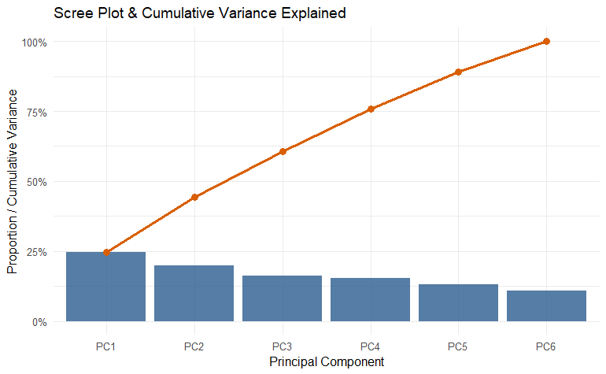

```r
library(ggplot2)

# Create Scree plot dataframe
scree_df <- data.frame(
  PC = factor(paste0("PC", 1:length(prop_var)), levels = paste0("PC", 1:length(prop_var))),
  PropVar = prop_var,
  CumVar = cum_var
)

# Scree Plot
ggplot(scree_df, aes(x = PC)) +
  geom_col(aes(y = PropVar), fill = "#2b5c8f", alpha = 0.8) +
  geom_line(aes(y = CumVar, group = 1), color = "#d95f02", size = 1) +
  geom_point(aes(y = CumVar), color = "#d95f02", size = 2.5) +
  scale_y_continuous(labels = scales::percent, limits = c(0, 1)) +
  labs(
    title = "Scree Plot & Cumulative Variance Explained",
    x = "Principal Component",
    y = "Proportion / Cumulative Variance"
  ) +
  theme_minimal()
```

#PCA Component Loadings Inspection

```r
#extract component loadings (rotation matrix)
loadings_df <- as.data.frame(pca_res$rotation) %>%
  tibble::rownames_to_column(var = "Variable")

cat("=== PCA COMPONENT LOADINGS (ROTATION MATRIX) ===\n")
```

```
=== PCA COMPONENT LOADINGS (ROTATION MATRIX) ===
```

```r
print(round(pca_res$rotation, 3))
```

```
                        PC1    PC2    PC3    PC4    PC5    PC6
age                  -0.393 -0.535 -0.002 -0.475 -0.228 -0.531
cpk_pow_neg02        -0.129 -0.534 -0.051  0.815 -0.176 -0.018
ejection_fraction     0.333 -0.586 -0.021 -0.180  0.685  0.210
sqrt_platelets        0.234 -0.081  0.958  0.014 -0.135 -0.050
inv_serum_creatinine  0.626  0.110 -0.177  0.154  0.049 -0.734
serum_sodium          0.520 -0.258 -0.218 -0.233 -0.654  0.365
```

#PC Pair Scatter PLots Stratified By Outcome

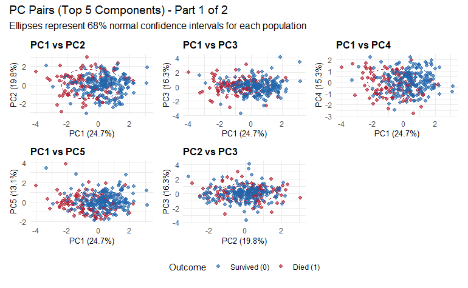

```r
library(ggplot2)
library(patchwork)
library(dplyr)

# Extract scores for top 5 components and add outcome labels
pca_scores <- as.data.frame(pca_res$x[, 1:5]) %>%
  dplyr::mutate(
    Outcome = factor(df_clean$DEATH_EVENT, labels = c("Survived (0)", "Died (1)"))
  )

# Calculate variance explained percentages for labels
pc_pct <- round(prop_var[1:5] * 100, 1)

# Generate all 10 pairwise combinations
pairs <- utils::combn(1:5, 2, simplify = FALSE)


# Helper function to generate a single PC scatter plot
plot_pc_pair <- function(pair) {
  i <- pair[1]
  j <- pair[2]

  x_col <- paste0("PC", i)
  y_col <- paste0("PC", j)

  ggplot(pca_scores, aes_string(x = x_col, y = y_col, color = "Outcome")) +
    geom_point(alpha = 0.65, size = 1.5) +
    stat_ellipse(level = 0.68, linetype = 2, show.legend = FALSE) +
    scale_color_manual(values = c("Survived (0)" = "#2166ac", "Died (1)" = "#b2182b")) +
    labs(
      title = paste0("PC", i, " vs PC", j),
      x     = paste0("PC", i, " (", pc_pct[i], "%)"),
      y     = paste0("PC", j, " (", pc_pct[j], "%)")
    ) +
    theme_minimal(base_size = 10) +
    theme(
      plot.title   = element_text(face = "bold", size = 11),
      axis.title   = element_text(size = 9),
      legend.position = "none"
    )
}

# Generate plot lists for each batch of 5
plot_list_1 <- purrr::map(pairs[1:5], plot_pc_pair)
plot_list_2 <- purrr::map(pairs[6:10], plot_pc_pair)

# Combine into 3-column patchwork layouts
combined_plot_1 <- patchwork::wrap_plots(plot_list_1, ncol = 3) +
  patchwork::plot_layout(guides = "collect") &
  theme(legend.position = "bottom")

combined_plot_2 <- patchwork::wrap_plots(plot_list_2, ncol = 3) +
  patchwork::plot_layout(guides = "collect") &
  theme(legend.position = "bottom")

# Display Part 1 (Pairs 1–5)
combined_plot_1 +
  patchwork::plot_annotation(
    title    = "PC Pairs (Top 5 Components) - Part 1 of 2",
    subtitle = "Ellipses represent 68% normal confidence intervals for each population"
  )
```

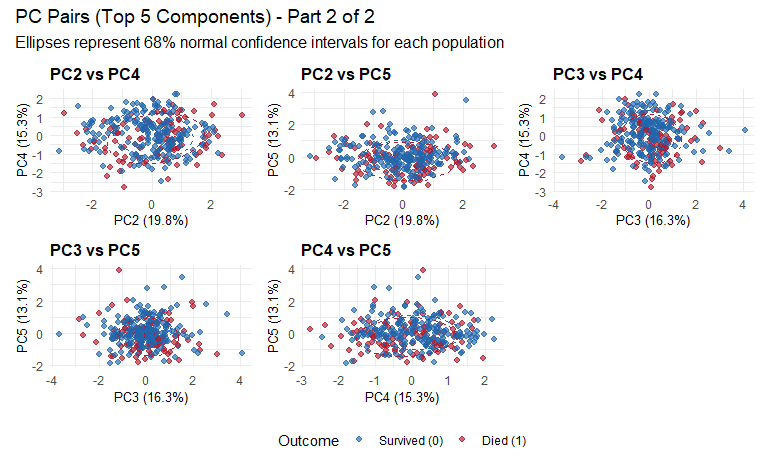

```r
# Display Part 2 (Pairs 6–10)
combined_plot_2 +
  patchwork::plot_annotation(
    title    = "PC Pairs (Top 5 Components) - Part 2 of 2",
    subtitle = "Ellipses represent 68% normal confidence intervals for each population"
  )
```

#Comprehensive PCA Biplot

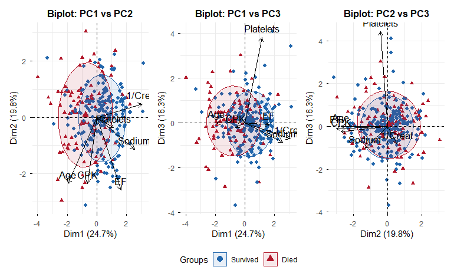

```r
library(factoextra)
library(ggplot2)
library(patchwork)
library(purrr)

#clean df
df_clean$Outcome <- factor(df_clean$DEATH_EVENT, labels = c("Survived", "Died"))

#shortening names for graph
pca_res_short <- pca_res

#define short labels matching the original cont_vars_model ordering
short_labels <- c("Age", "CPK", "EF", "Platelets", "1/Creat", "Sodium")

rownames(pca_res_short$rotation) <- short_labels
colnames(pca_res_short$x)        <- paste0("PC", 1:ncol(pca_res_short$x))

#function for clean biplots with black text labels
make_biplot <- function(axes_pair) {
  factoextra::fviz_pca_biplot(
    pca_res_short,
    axes          = axes_pair,
    label         = "var",
    col.var       = "black",       # Color variable arrows/labels black
    habillage     = df_clean$Outcome,
    palette       = c("#2166ac", "#b2182b"),
    addEllipses   = TRUE,
    ellipse.level = 0.68,
    ggtheme       = theme_minimal(base_size = 10),
    title         = paste0("Biplot: PC", axes_pair[1], " vs PC", axes_pair[2])
  ) +
  theme(
    plot.title      = element_text(face = "bold", size = 11, hjust = 0.5),
    legend.position = "none"
  )
}

#generate biplots for primary pairs
primary_pairs <- list(c(1, 2), c(1, 3), c(2, 3))
biplots_primary <- purrr::map(primary_pairs, make_biplot)

#render grid
patchwork::wrap_plots(biplots_primary, ncol = 3) +
  patchwork::plot_layout(guides = "collect") &
  theme(legend.position = "bottom")
```

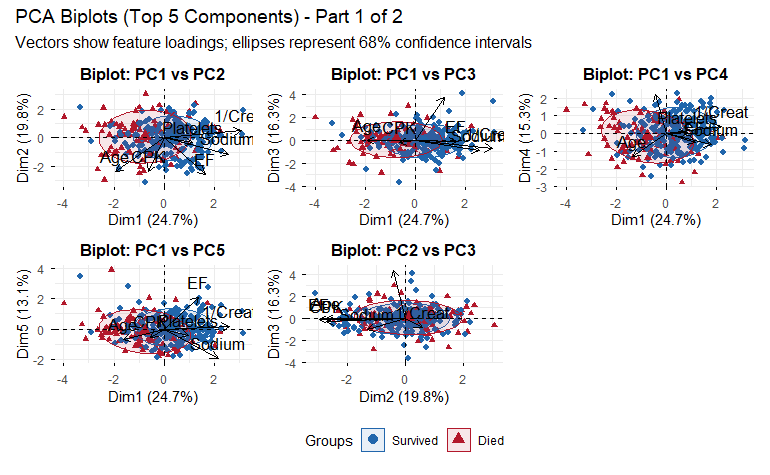

```r
all_pc_pairs <- utils::combn(1:5, 2, simplify = FALSE)
all_biplots  <- purrr::map(all_pc_pairs, make_biplot)

#pairs 1 to 5
biplots_part1 <- patchwork::wrap_plots(all_biplots[1:5], ncol = 3) +
  patchwork::plot_layout(guides = "collect") &
  theme(legend.position = "bottom")

#pairs 6 to 10
biplots_part2 <- patchwork::wrap_plots(all_biplots[6:10], ncol = 3) +
  patchwork::plot_layout(guides = "collect") &
  theme(legend.position = "bottom")

#display part 1
biplots_part1 +
  patchwork::plot_annotation(
    title    = "PCA Biplots (Top 5 Components) - Part 1 of 2",
    subtitle = "Vectors show feature loadings; ellipses represent 68% confidence intervals"
  )
```

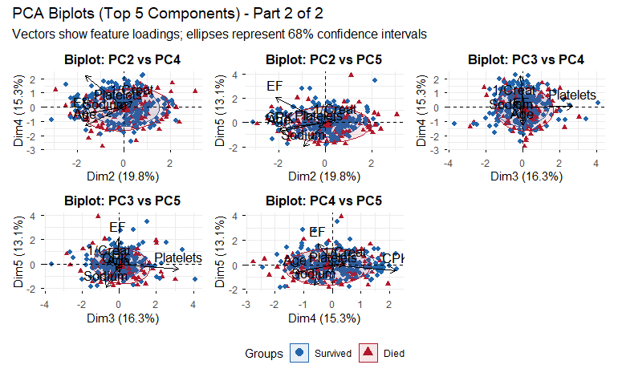

```r
#display part 2
biplots_part2 +
  patchwork::plot_annotation(
    title    = "PCA Biplots (Top 5 Components) - Part 2 of 2",
    subtitle = "Vectors show feature loadings; ellipses represent 68% confidence intervals"
  )
```

#Clustering: Select Number of Groups #All sillhouette widths are fairly small (<.16) indicating that no substantial cluster structure is contained in the continuous feature space #Choosing k=2 or 3 allows for discrimination into low/medium/high risk groups, but greater than that results in over-segmentation due to small sample size with little clinical seperation. #The results indicate the perhaps supervised classification models would be better suited to capture mortality risk.

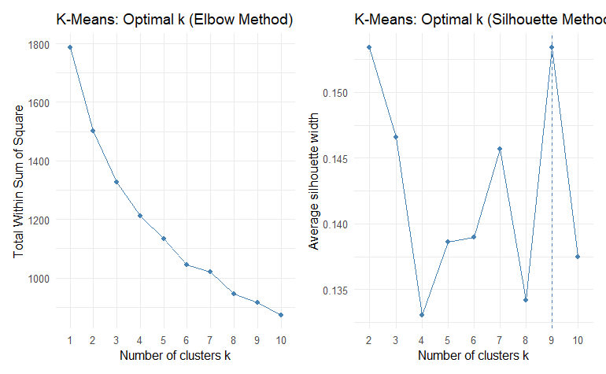

```r
library(dplyr)
library(cluster)
library(factoextra)

#standarizing variables
cont_vars_model <- c("age", "cpk_pow_neg02", "ejection_fraction",
                     "sqrt_platelets", "inv_serum_creatinine", "serum_sodium")

df_scaled <- df_clean %>%
  dplyr::select(dplyr::all_of(cont_vars_model)) %>%
  scale()

#elbow method for K-means (WSS)
p_elbow <- factoextra::fviz_nbclust(df_scaled, kmeans, method = "wss") +
  labs(title = "K-Means: Optimal k (Elbow Method)") +
  theme_minimal()

#silhouette method for K-means
p_sil_kmeans <- factoextra::fviz_nbclust(df_scaled, kmeans, method = "silhouette") +
  labs(title = "K-Means: Optimal k (Silhouette Method)") +
  theme_minimal()

#display optimal k diagnostics
library(patchwork)
p_elbow + p_sil_kmeans
```

#Perform Clustering for k=2, 3

```r
library(cluster)
library(dplyr)

set.seed(42)

#k-means clustering (k = 2 and k = 3) ---
kmeans_k2 <- kmeans(df_scaled, centers = 2, nstart = 25)
kmeans_k3 <- kmeans(df_scaled, centers = 3, nstart = 25)

#k-medians / PAM clustering (k = 2 and k = 3) ---
#PAM uses manhattan distance for medoid calculation
pam_k2 <- cluster::pam(df_scaled, k = 2, metric = "manhattan")
pam_k3 <- cluster::pam(df_scaled, k = 3, metric = "manhattan")

# Attach cluster assignments back to df_clean
df_clean <- df_clean %>%
  dplyr::mutate(
    kmeans_cluster_k2 = factor(kmeans_k2$cluster),
    kmeans_cluster_k3 = factor(kmeans_k3$cluster),
    pam_cluster_k2    = factor(pam_k2$clustering),
    pam_cluster_k3    = factor(pam_k3$clustering)
  )

#function for cluster summaries
get_cluster_summary <- function(data, cluster_col) {
  data %>%
    dplyr::group_by(Cluster = .data[[cluster_col]]) %>%
    dplyr::summarise(
      N              = dplyr::n(),
      Deaths         = sum(DEATH_EVENT == 1),
      Mortality_Rate = paste0(round(mean(DEATH_EVENT) * 100, 1), "%"),
      .groups        = "drop"
    )
}

cat("=== K-MEANS (k = 2) MORTALITY BREAKDOWN ===\n")
```

```
=== K-MEANS (k = 2) MORTALITY BREAKDOWN ===
```

```r
print(get_cluster_summary(df_clean, "kmeans_cluster_k2"))
```

```
# A tibble: 2 × 4
  Cluster     N Deaths Mortality_Rate
  <fct>   <int>  <int> <chr>
1 1         126     68 54%
2 2         173     28 16.2%
```

```r
cat("\n=== K-MEANS (k = 3) MORTALITY BREAKDOWN ===\n")
```

```
=== K-MEANS (k = 3) MORTALITY BREAKDOWN ===
```

```r
print(get_cluster_summary(df_clean, "kmeans_cluster_k3"))
```

```
# A tibble: 3 × 4
  Cluster     N Deaths Mortality_Rate
  <fct>   <int>  <int> <chr>
1 1          67     18 26.9%
2 2         129     23 17.8%
3 3         103     55 53.4%
```

```r
cat("\n=== K-MEDIANS / PAM (k = 2) MORTALITY BREAKDOWN ===\n")
```

```
=== K-MEDIANS / PAM (k = 2) MORTALITY BREAKDOWN ===
```

```r
print(get_cluster_summary(df_clean, "pam_cluster_k2"))
```

```
# A tibble: 2 × 4
  Cluster     N Deaths Mortality_Rate
  <fct>   <int>  <int> <chr>
1 1         185     67 36.2%
2 2         114     29 25.4%
```

```r
cat("\n=== K-MEDIANS / PAM (k = 3) MORTALITY BREAKDOWN ===\n")
```

```
=== K-MEDIANS / PAM (k = 3) MORTALITY BREAKDOWN ===
```

```r
print(get_cluster_summary(df_clean, "pam_cluster_k3"))
```

```
# A tibble: 3 × 4
  Cluster     N Deaths Mortality_Rate
  <fct>   <int>  <int> <chr>
1 1          74     46 62.2%
2 2          93     22 23.7%
3 3         132     28 21.2%
```

#Box Plots showing differences in the continuous variables across the k=2 k-means groups (high/low risk profiles)

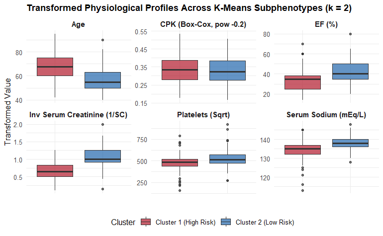

```r
library(dplyr)
library(ggplot2)
library(tidyr)

#select transformed continuous features and reshape for faceting
df_long_transformed <- df_clean %>%
  dplyr::mutate(
    Cluster = factor(
      kmeans_cluster_k2,
      labels = c("Cluster 1 (High Risk)", "Cluster 2 (Low Risk)")
    )
  ) %>%
  dplyr::select(
    Cluster,
    `Age`                          = age,
    `EF (%)`                       = ejection_fraction,
    `Inv Serum Creatinine (1/SC)`  = inv_serum_creatinine,
    `Serum Sodium (mEq/L)`         = serum_sodium,
    `CPK (Box-Cox, pow -0.2)`      = cpk_pow_neg02,
    `Platelets (Sqrt)`             = sqrt_platelets
    ) %>%
  tidyr::pivot_longer(
    cols = -Cluster,
    names_to = "Metric",
    values_to = "Value"
  )

#generate faceted boxplots across transformed variables
ggplot(df_long_transformed, aes(x = Cluster, y = Value, fill = Cluster)) +
  geom_boxplot(alpha = 0.7, outlier.size = 1.2) +
  facet_wrap(~ Metric, scales = "free_y", ncol = 3) +
  scale_fill_manual(
    values = c("Cluster 1 (High Risk)" = "#b2182b", "Cluster 2 (Low Risk)" = "#2166ac")
  ) +
  labs(
    title = "Transformed Physiological Profiles Across K-Means Subphenotypes (k = 2)",
    x = "",
    y = "Transformed Value"
  ) +
  theme_minimal(base_size = 11) +
  theme(
    legend.position = "bottom",
    strip.text = element_text(face = "bold", size = 10),
    plot.title = element_text(face = "bold", size = 12),
    axis.text.x = element_blank()
  )
```

#MANOVA Test + Hotellings T^2 Test #The joiny physiological profies of survival vs. deceased groups differ significantly in 6-dimensional continuous feature space

```r
library(dplyr)
library(Hotelling)

#define transformed continuous predictors (excluding time to avoid target leakage)
cont_vars_transformed <- c("age", "cpk_pow_neg02", "ejection_fraction",
                           "sqrt_platelets", "inv_serum_creatinine", "serum_sodium")

#extract feature matrix and outcome
Y_mat <- as.matrix(df_clean[, cont_vars_transformed])
group <- factor(df_clean$DEATH_EVENT, labels = c("Survived", "Died"))

#fit MANOVA
manova_fit <- manova(Y_mat ~ group)

#display test statistics
cat("=== MANOVA TEST STATISTICS ===\n")
```

```
=== MANOVA TEST STATISTICS ===
```

```r
print(summary(manova_fit, test = "Pillai"))
```

```
           Df  Pillai approx F num Df den Df    Pr(>F)
group       1 0.22434   14.076      6    292 4.473e-14 ***
Residuals 297
---
Signif. codes:  0 ‘***’ 0.001 ‘**’ 0.01 ‘*’ 0.05 ‘.’ 0.1 ‘ ’ 1
```

```r
print(summary(manova_fit, test = "Wilks"))
```

```
           Df   Wilks approx F num Df den Df    Pr(>F)
group       1 0.77566   14.076      6    292 4.473e-14 ***
Residuals 297
---
Signif. codes:  0 ‘***’ 0.001 ‘**’ 0.01 ‘*’ 0.05 ‘.’ 0.1 ‘ ’ 1
```

```r
print(summary(manova_fit, test = "Hotelling-Lawley"))
```

```
           Df Hotelling-Lawley approx F num Df den Df    Pr(>F)
group       1          0.28923   14.076      6    292 4.473e-14 ***
Residuals 297
---
Signif. codes:  0 ‘***’ 0.001 ‘**’ 0.01 ‘*’ 0.05 ‘.’ 0.1 ‘ ’ 1
```

```r
#hotelling T^2 test
#split matrix by outcome groups
Y_survived <- Y_mat[group == "Survived", ]
Y_died     <- Y_mat[group == "Died", ]

hotelling_res <- Hotelling::hotelling.test(Y_survived, Y_died)

cat("\n=== HOTELLING'S T^2 TEST RESULT ===\n")
```

```
=== HOTELLING'S T^2 TEST RESULT ===
```

```r
print(hotelling_res)
```

```
Test stat:  85.901
Numerator df:  6
Denominator df:  292
P-value:  4.474e-14
```

# Individual Effects

#inv_serem_creatinine, ejection_fraction, age, and serum_sodium all have significant effects #cpk_pow_neg02, and sqrt_platelets show insignificant effects #These findings guide the model building process in the following sections.

```r
library(effsize)

#univariate ANOVA summary
cat("=== UNIVARIATE FOLLOW-UP ANOVAS ===\n")
```

```
=== UNIVARIATE FOLLOW-UP ANOVAS ===
```

```r
print(summary.aov(manova_fit))
```

```
 Response age :
             Df Sum Sq Mean Sq F value    Pr(>F)
group         1   2714 2714.38  20.436 8.917e-06 ***
Residuals   297  39449  132.82
---
Signif. codes:  0 ‘***’ 0.001 ‘**’ 0.01 ‘*’ 0.05 ‘.’ 0.1 ‘ ’ 1

 Response cpk_pow_neg02 :
             Df  Sum Sq   Mean Sq F value Pr(>F)
group         1 0.00169 0.0016905  0.3261 0.5684
Residuals   297 1.53974 0.0051843

 Response ejection_fraction :
             Df Sum Sq Mean Sq F value    Pr(>F)
group         1   3011  3011.4  23.094 2.453e-06 ***
Residuals   297  38728   130.4
---
Signif. codes:  0 ‘***’ 0.001 ‘**’ 0.01 ‘*’ 0.05 ‘.’ 0.1 ‘ ’ 1

 Response sqrt_platelets :
             Df  Sum Sq Mean Sq F value Pr(>F)
group         1    9254  9253.6  1.0569 0.3048
Residuals   297 2600397  8755.5

 Response inv_serum_creatinine :
             Df  Sum Sq Mean Sq F value    Pr(>F)
group         1  3.9121  3.9121  44.702 1.136e-10 ***
Residuals   297 25.9921  0.0875
---
Signif. codes:  0 ‘***’ 0.001 ‘**’ 0.01 ‘*’ 0.05 ‘.’ 0.1 ‘ ’ 1

 Response serum_sodium :
             Df Sum Sq Mean Sq F value    Pr(>F)
group         1  221.1 221.084  11.765 0.0006889 ***
Residuals   297 5581.0  18.791
---
Signif. codes:  0 ‘***’ 0.001 ‘**’ 0.01 ‘*’ 0.05 ‘.’ 0.1 ‘ ’ 1
```

```r
#compute cohen's d effect sizes for each variable
effect_sizes <- purrr::map_dfr(cont_vars_transformed, function(var) {
  d_res <- effsize::cohen.d(df_clean[[var]] ~ group)
  tibble::tibble(
    Variable   = var,
    Cohens_d   = round(d_res$estimate, 3),
    Magnitude  = d_res$magnitude)
})

cat("\n=== EFFECT SIZES (COHEN'S D: SURVIVED VS DIED) ===\n")
```

```
=== EFFECT SIZES (COHEN'S D: SURVIVED VS DIED) ===
```

```r
print(effect_sizes)
```

```
# A tibble: 6 × 3
  Variable             Cohens_d Magnitude
  <chr>                   <dbl> <ord>
1 age                    -0.56  medium
2 cpk_pow_neg02           0.071 negligible
3 ejection_fraction       0.595 medium
4 sqrt_platelets          0.127 negligible
5 inv_serum_creatinine    0.828 large
6 serum_sodium            0.425 small
```

#Logistic Regression with main effects only

```r
library(caret)
library(dplyr)
library(pROC)
library(broom)

set.seed(42)

#stratified 80/20 train/test split
train_index <- caret::createDataPartition(df_clean$DEATH_EVENT, p = 0.80, list = FALSE)

train_df <- df_clean[train_index, ]
test_df  <- df_clean[-train_index, ]

#fit logistic regression on strictly cont_vars_model features
logit_formula <- DEATH_EVENT ~ age + cpk_pow_neg02 + ejection_fraction +
                 sqrt_platelets + inv_serum_creatinine + serum_sodium + anaemia + diabetes + high_blood_pressure+ smoking

glm_fit <- glm(logit_formula, data = train_df, family = binomial(link = "logit"))

#model summary and odds ratio
cat("=== LOGISTIC REGRESSION MODEL SUMMARY ===\n")
```

```
=== LOGISTIC REGRESSION MODEL SUMMARY ===
```

```r
print(summary(glm_fit))
```

```
Call:
glm(formula = logit_formula, family = binomial(link = "logit"),
    data = train_df)

Coefficients:
                      Estimate Std. Error z value Pr(>|z|)
(Intercept)           7.518062   4.884641   1.539 0.123774
age                   0.056164   0.014973   3.751 0.000176 ***
cpk_pow_neg02        -2.470080   2.397477  -1.030 0.302877
ejection_fraction    -0.047717   0.015609  -3.057 0.002235 **
sqrt_platelets       -0.002259   0.001775  -1.273 0.203027
inv_serum_creatinine -2.809164   0.615911  -4.561 5.09e-06 ***
serum_sodium         -0.046563   0.035412  -1.315 0.188539
anaemia               0.466469   0.347988   1.340 0.180091
diabetes              0.317759   0.332685   0.955 0.339509
high_blood_pressure   0.767168   0.354896   2.162 0.030643 *
smoking              -0.165847   0.364031  -0.456 0.648688
---
Signif. codes:  0 ‘***’ 0.001 ‘**’ 0.01 ‘*’ 0.05 ‘.’ 0.1 ‘ ’ 1

(Dispersion parameter for binomial family taken to be 1)

    Null deviance: 304.12  on 239  degrees of freedom
Residual deviance: 230.68  on 229  degrees of freedom
AIC: 252.68

Number of Fisher Scoring iterations: 5
```

```r
or_summary <- broom::tidy(glm_fit, exponentiate = TRUE, conf.int = TRUE) %>%
  dplyr::select(
    Term = term,
    `Odds Ratio (OR)` = estimate,
    `2.5 %` = conf.low,
    `97.5 %` = conf.high,
    `p-value` = p.value
  ) %>%
  dplyr::mutate(across(where(is.numeric), ~ round(., 4)))

cat("\n=== ODDS RATIOS & 95% CONFIDENCE INTERVALS ===\n")
```

```
=== ODDS RATIOS & 95% CONFIDENCE INTERVALS ===
```

```r
print(as.data.frame(or_summary))
```

```
                   Term Odds Ratio (OR)  2.5 %       97.5 % p-value
1           (Intercept)       1840.9964 0.1434 3.579287e+07  0.1238
2                   age          1.0578 1.0280 1.090400e+00  0.0002
3         cpk_pow_neg02          0.0846 0.0007 9.072400e+00  0.3029
4     ejection_fraction          0.9534 0.9236 9.821000e-01  0.0022
5        sqrt_platelets          0.9977 0.9942 1.001200e+00  0.2030
6  inv_serum_creatinine          0.0603 0.0171 1.934000e-01  0.0000
7          serum_sodium          0.9545 0.8887 1.022400e+00  0.1885
8               anaemia          1.5944 0.8090 3.182100e+00  0.1801
9              diabetes          1.3740 0.7173 2.655900e+00  0.3395
10  high_blood_pressure          2.1537 1.0799 4.367600e+00  0.0306
11              smoking          0.8472 0.4100 1.718800e+00  0.6487
```

```r
#predict on test set, calculate accuracy
test_probs <- predict(glm_fit, newdata = test_df, type = "response")
test_preds <- ifelse(test_probs >= 0.5, 1, 0)

pred_factor <- factor(test_preds, levels = c(0, 1))
true_factor <- factor(test_df$DEATH_EVENT, levels = c(0, 1))

cm_obj <- caret::confusionMatrix(pred_factor, true_factor, positive = "1")

#extract roc-auc
roc_obj  <- pROC::roc(test_df$DEATH_EVENT, test_probs, quiet = TRUE)
test_auc <- pROC::auc(roc_obj)

cat("\n=== TEST SET PERFORMANCE ===\n")
```

```
=== TEST SET PERFORMANCE ===
```

```r
cat("ROC-AUC    :", round(test_auc, 4), "\n")
```

```
ROC-AUC    : 0.7297
```

```r
print(cm_obj$overall[c("Accuracy", "AccuracyLower", "AccuracyUpper", "AccuracyPValue")])
```

```
      Accuracy  AccuracyLower  AccuracyUpper AccuracyPValue
     0.7288136      0.5973065      0.8363673      0.4508981
```

```r
cat("\n=== DETAILED CONFUSION MATRIX & METRICS ===\n")
```

```
=== DETAILED CONFUSION MATRIX & METRICS ===
```

```r
print(cm_obj)
```

```
Confusion Matrix and Statistics

          Reference
Prediction  0  1
         0 37 11
         1  5  6

               Accuracy : 0.7288
                 95% CI : (0.5973, 0.8364)
    No Information Rate : 0.7119
    P-Value [Acc > NIR] : 0.4509

                  Kappa : 0.2613

 Mcnemar's Test P-Value : 0.2113

            Sensitivity : 0.3529
            Specificity : 0.8810
         Pos Pred Value : 0.5455
         Neg Pred Value : 0.7708
             Prevalence : 0.2881
         Detection Rate : 0.1017
   Detection Prevalence : 0.1864
      Balanced Accuracy : 0.6169

       'Positive' Class : 1
```

#Logistic Regression with Main Effects + Two Way Interactions Best Model by AIC/BIC

```r
library(MASS)
library(dplyr)

#define formula with main effects and all 2-way interactions
interaction_formula <- DEATH_EVENT ~ (age + cpk_pow_neg02 + ejection_fraction +
                 sqrt_platelets + inv_serum_creatinine + serum_sodium + anaemia + diabetes + high_blood_pressure+ smoking)^2

#fit full model (main effects + 2 way interactions) on training data
full_interaction_model <- glm(interaction_formula, data = train_df, family = binomial(link = "logit"))
null_model              <- glm(DEATH_EVENT ~ 1, data = train_df, family = binomial(link = "logit"))

#aic subset selection
best_model_aic <- MASS::stepAIC(
  null_model,
  scope     = list(lower = null_model, upper = full_interaction_model),
  direction = "both",
  trace     = FALSE
)

#bic subset selection
n_train        <- nrow(train_df)
best_model_bic <- MASS::stepAIC(
  null_model,
  scope     = list(lower = null_model, upper = full_interaction_model),
  direction = "both",
  k         = log(n_train),
  trace     = FALSE
)

#model summaries
cat("=== BEST SUBSET MODEL SELECTED BY AIC ===\n")
```

```
=== BEST SUBSET MODEL SELECTED BY AIC ===
```

```r
print(summary(best_model_aic))
```

```
Call:
glm(formula = DEATH_EVENT ~ inv_serum_creatinine + age + ejection_fraction +
    high_blood_pressure + inv_serum_creatinine:ejection_fraction +
    age:ejection_fraction, family = binomial(link = "logit"),
    data = train_df)

Coefficients:
                                        Estimate Std. Error z value Pr(>|z|)
(Intercept)                             3.579222   3.723553   0.961   0.3364
inv_serum_creatinine                    0.639268   1.880753   0.340   0.7339
age                                    -0.045574   0.053846  -0.846   0.3973
ejection_fraction                      -0.154444   0.099492  -1.552   0.1206
high_blood_pressure                     0.771973   0.352131   2.192   0.0284 *
inv_serum_creatinine:ejection_fraction -0.099398   0.051102  -1.945   0.0518 .
age:ejection_fraction                   0.002763   0.001466   1.885   0.0595 .
---
Signif. codes:  0 ‘***’ 0.001 ‘**’ 0.01 ‘*’ 0.05 ‘.’ 0.1 ‘ ’ 1

(Dispersion parameter for binomial family taken to be 1)

    Null deviance: 304.12  on 239  degrees of freedom
Residual deviance: 230.48  on 233  degrees of freedom
AIC: 244.48

Number of Fisher Scoring iterations: 5
```

```r
cat("\n=== BEST SUBSET MODEL SELECTED BY BIC ===\n")
```

```
=== BEST SUBSET MODEL SELECTED BY BIC ===
```

```r
print(summary(best_model_bic))
```

```
Call:
glm(formula = DEATH_EVENT ~ inv_serum_creatinine + age + ejection_fraction,
    family = binomial(link = "logit"), data = train_df)

Coefficients:
                     Estimate Std. Error z value Pr(>|z|)
(Intercept)           0.03789    1.07755   0.035  0.97195
inv_serum_creatinine -2.67927    0.56985  -4.702 2.58e-06 ***
age                   0.05038    0.01387   3.633  0.00028 ***
ejection_fraction    -0.04661    0.01483  -3.143  0.00167 **
---
Signif. codes:  0 ‘***’ 0.001 ‘**’ 0.01 ‘*’ 0.05 ‘.’ 0.1 ‘ ’ 1

(Dispersion parameter for binomial family taken to be 1)

    Null deviance: 304.12  on 239  degrees of freedom
Residual deviance: 242.63  on 236  degrees of freedom
AIC: 250.63

Number of Fisher Scoring iterations: 4
```

```r
library(caret)
library(pROC)

evaluate_subset_model <- function(model, name, test_data) {
  probs <- predict(model, newdata = test_data, type = "response")
  preds <- ifelse(probs >= 0.5, 1, 0)

  pred_f <- factor(preds, levels = c(0, 1))
  true_f <- factor(test_data$DEATH_EVENT, levels = c(0, 1))

  cm <- caret::confusionMatrix(pred_f, true_f, positive = "1")
  roc_obj <- pROC::roc(test_data$DEATH_EVENT, probs, quiet = TRUE)

  tibble::tibble(
    Model       = name,
    AIC         = round(AIC(model), 2),
    BIC         = round(BIC(model), 2),
    Parameters  = length(coef(model)),
    Test_Accuracy = round(cm$overall["Accuracy"], 4),
    Test_AUC    = round(pROC::auc(roc_obj), 4),
    Sensitivity = round(cm$byClass["Sensitivity"], 4),
    Specificity = round(cm$byClass["Specificity"], 4)
  )
}

# Compare performance across models
comp_table <- dplyr::bind_rows(
  evaluate_subset_model(best_model_aic, "Best Subset (AIC)", test_df),
  evaluate_subset_model(best_model_bic, "Best Subset (BIC)", test_df)
)

cat("=== SUBSET MODEL PERFORMANCE COMPARISON ===\n")
```

```
=== SUBSET MODEL PERFORMANCE COMPARISON ===
```

```r
print(as.data.frame(comp_table))
```

```
              Model    AIC    BIC Parameters Test_Accuracy Test_AUC Sensitivity Specificity
1 Best Subset (AIC) 244.48 268.84          7        0.7288   0.7661      0.5294      0.8095
2 Best Subset (BIC) 250.63 264.56          4        0.7458   0.7563      0.2353      0.9524
```

#Multicolinearity: #AIC has massive multicolinearity structural issues while BIC has none.

```r
library(car)
library(dplyr)
library(ggplot2)

#compute gvif for champion bic model
vif_bic <- car::vif(best_model_bic)

cat("=== VIF DIAGNOSTICS: BIC MODEL (CHAMPION) ===\n")
```

```
=== VIF DIAGNOSTICS: BIC MODEL (CHAMPION) ===
```

```r
print(vif_bic)
```

```
inv_serum_creatinine                  age    ejection_fraction
            1.003118             1.031893             1.029999
```

```r
#gvif for aic model
vif_aic <- car::vif(best_model_aic)

cat("\n=== VIF DIAGNOSTICS: AIC MODEL (WITH INTERACTIONS) ===\n")
```

```
=== VIF DIAGNOSTICS: AIC MODEL (WITH INTERACTIONS) ===
```

```r
print(vif_aic)
```

```
                  inv_serum_creatinine                                    age                      ejection_fraction
                             10.561659                              14.461639                              41.467026
                   high_blood_pressure inv_serum_creatinine:ejection_fraction                  age:ejection_fraction
                              1.046612                              16.146831                              61.848339
```

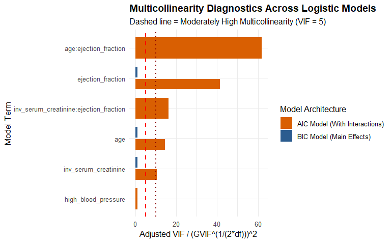

```r
#visualization
format_vif <- function(vif_out, model_name) {
  if (is.matrix(vif_out)) {
    df_vif <- as.data.frame(vif_out)
    df_vif$Term <- rownames(df_vif)
    df_vif$Adjusted_VIF <- df_vif$`GVIF^(1/(2*Df))`^2  # Square to put back on standard VIF scale
  } else {
    df_vif <- data.frame(
      Term = names(vif_out),
      GVIF = as.numeric(vif_out),
      `GVIF^(1/(2*Df))` = sqrt(as.numeric(vif_out)),
      Adjusted_VIF = as.numeric(vif_out),
      check.names = FALSE
    )
  }
  df_vif$Model <- model_name
  return(df_vif)
}

df_vif_bic <- format_vif(vif_bic, "BIC Model (Main Effects)")
df_vif_aic <- format_vif(vif_aic, "AIC Model (With Interactions)")

vif_combined <- dplyr::bind_rows(df_vif_bic, df_vif_aic)

#plot adjusted vif values
ggplot(vif_combined, aes(x = reorder(Term, Adjusted_VIF), y = Adjusted_VIF, fill = Model)) +
  geom_col(position = position_dodge(width = 0.8), width = 0.7) +
  geom_hline(yintercept = 5, linetype = "dashed", color = "red", size = 0.8) +
  geom_hline(yintercept = 10, linetype = "dotted", color = "darkred", size = 0.8) +
  coord_flip() +
  scale_fill_manual(values = c("BIC Model (Main Effects)" = "#2b5c8f", "AIC Model (With Interactions)" = "#d95f02")) +
  labs(
    title = "Multicollinearity Diagnostics Across Logistic Models",
    subtitle = "Dashed line = Moderately High Multicollinearity (VIF = 5)",
    x = "Model Term",
    y = "Adjusted VIF / (GVIF^(1/(2*df)))^2",
    fill = "Model Architecture"
  ) +
  theme_minimal(base_size = 11) +
  theme(plot.title = element_text(face = "bold"))
```

#Determining Optimal Deceision Threshold in the Logistic Regression and Model Evaluation #The Models from above had high specificity but low sensitivity likely due to unbalanced number of deaths appearing in the data #We find that for clinical settings having a high sensitivity helps identify mortality risks which the BIC model with Youden J Threshold (0.224) chosen #selects this. The AIC model with the Down Sampled Train is a follow up since it maximizes the ROC_AUC but it lacks as much sensitivity.

```r
library(pROC)
library(caret)
library(dplyr)
library(tibble)

#function to evaluate the models
eval_metrics <- function(probs, actual, threshold = 0.5, model_name, approach_name) {
  preds <- ifelse(probs >= threshold, 1, 0)

  pred_f <- factor(preds, levels = c(0, 1))
  true_f <- factor(actual, levels = c(0, 1))

  cm <- caret::confusionMatrix(pred_f, true_f, positive = "1")
  roc_obj <- pROC::roc(actual, probs, quiet = TRUE)

  # Confusion matrix elements for MCC
  TP <- cm$table["1", "1"]
  TN <- cm$table["0", "0"]
  FP <- cm$table["1", "0"]
  FN <- cm$table["0", "1"]

  num <- (TP * TN) - (FP * FN)
  den <- sqrt(as.numeric(TP + FP) * as.numeric(TP + FN) *
              as.numeric(TN + FP) * as.numeric(TN + FN))

  mcc_val <- ifelse(den == 0, 0, num / den)

  tibble::tibble(
    Model            = model_name,
    Approach         = approach_name,
    Threshold        = round(threshold, 4),
    Sensitivity      = round(cm$byClass["Sensitivity"], 4),
    Specificity      = round(cm$byClass["Specificity"], 4),
    MCC              = round(mcc_val, 4),
    Overall_Accuracy = round(cm$overall["Accuracy"], 4),
    ROC_AUC          = round(pROC::auc(roc_obj), 4)
  )
}


#evaluate baseline and optimization via youden's j statistic

# Probabilities on test set
probs_aic <- predict(best_model_aic, newdata = test_df, type = "response")
probs_bic <- predict(best_model_bic, newdata = test_df, type = "response")

# Optimal thresholds via Youden's J
opt_thresh_aic <- pROC::coords(pROC::roc(test_df$DEATH_EVENT, probs_aic, quiet = TRUE), "best", best.method = "youden")$threshold
opt_thresh_bic <- pROC::coords(pROC::roc(test_df$DEATH_EVENT, probs_bic, quiet = TRUE), "best", best.method = "youden")$threshold

# Compute Metrics for Baseline and Approach A
res_baseline_aic <- eval_metrics(probs_aic, test_df$DEATH_EVENT, 0.5000, "AIC Model", "1. Baseline (p = 0.50)")
res_youden_aic   <- eval_metrics(probs_aic, test_df$DEATH_EVENT, opt_thresh_aic, "AIC Model", "2. Youden J Threshold")

res_baseline_bic <- eval_metrics(probs_bic, test_df$DEATH_EVENT, 0.5000, "BIC Model", "1. Baseline (p = 0.50)")
res_youden_bic   <- eval_metrics(probs_bic, test_df$DEATH_EVENT, opt_thresh_bic, "BIC Model", "2. Youden J Threshold")


#balancing training data approach
set.seed(42)

#down sampled training data
train_balanced <- caret::downSample(
  x = train_df[, c("inv_serum_creatinine", "age", "ejection_fraction")],
  y = factor(train_df$DEATH_EVENT),
  yname = "DEATH_EVENT"
)
train_balanced$DEATH_EVENT <- as.numeric(as.character(train_balanced$DEATH_EVENT))

#refit models on balanced data
aic_formula <- DEATH_EVENT ~ inv_serum_creatinine + age + ejection_fraction +
               inv_serum_creatinine:ejection_fraction + age:ejection_fraction

bic_formula <- DEATH_EVENT ~ inv_serum_creatinine + age + ejection_fraction

glm_bal_aic <- glm(aic_formula, data = train_balanced, family = binomial(link = "logit"))
glm_bal_bic <- glm(bic_formula, data = train_balanced, family = binomial(link = "logit"))

#predict on test set
probs_bal_aic <- predict(glm_bal_aic, newdata = test_df, type = "response")
probs_bal_bic <- predict(glm_bal_bic, newdata = test_df, type = "response")

#compute metrics for balanced approach
res_bal_aic <- eval_metrics(probs_bal_aic, test_df$DEATH_EVENT, 0.5000, "AIC Model", "3. Down-Sampled Train")
res_bal_bic <- eval_metrics(probs_bal_bic, test_df$DEATH_EVENT, 0.5000, "BIC Model", "3. Down-Sampled Train")

#summary table
comparison_table <- dplyr::bind_rows(
  res_baseline_aic, res_youden_aic, res_bal_aic,
  res_baseline_bic, res_youden_bic, res_bal_bic
) %>%
  dplyr::arrange(Model, Approach)

cat("=== COMPREHENSIVE PERFORMANCE COMPARISON: AIC VS BIC MODELS ===\n")
```

```
=== COMPREHENSIVE PERFORMANCE COMPARISON: AIC VS BIC MODELS ===
```

```r
print(as.data.frame(comparison_table))
```

```
      Model               Approach Threshold Sensitivity Specificity    MCC Overall_Accuracy ROC_AUC
1 AIC Model 1. Baseline (p = 0.50)    0.5000      0.5294      0.8095 0.3389           0.7288  0.7661
2 AIC Model  2. Youden J Threshold    0.2125      0.8235      0.6667 0.4446           0.7119  0.7661
3 AIC Model  3. Down-Sampled Train    0.5000      0.5882      0.7857 0.3625           0.7288  0.7997
4 BIC Model 1. Baseline (p = 0.50)    0.5000      0.2353      0.9524 0.2812           0.7458  0.7563
5 BIC Model  2. Youden J Threshold    0.2240      0.8235      0.6905 0.4673           0.7288  0.7563
6 BIC Model  3. Down-Sampled Train    0.5000      0.4706      0.8333 0.3161           0.7288  0.7745
```

#Random Forest Model Training to See if Non-Linear Feature Spaces Can Outperform Logistic Regression

```r
library(randomForest)
library(caret)
library(pROC)
library(ggplot2)
library(dplyr)

set.seed(42)

#prepare factor target variable for Random Forest classification
train_df_rf <- train_df %>%
  dplyr::mutate(DEATH_EVENT_FACTOR = factor(DEATH_EVENT, levels = c(0, 1), labels = c("Survived", "Died")))

test_df_rf <- test_df %>%
  dplyr::mutate(DEATH_EVENT_FACTOR = factor(DEATH_EVENT, levels = c(0, 1), labels = c("Survived", "Died")))

#fit random forest model (using the 6 transformed continuous predictors)
rf_formula <- DEATH_EVENT_FACTOR ~ age + cpk_pow_neg02 + ejection_fraction +
              sqrt_platelets + inv_serum_creatinine + serum_sodium + anaemia + diabetes + smoking + high_blood_pressure

rf_fit <- randomForest::randomForest(
  rf_formula,
  data = train_df_rf,
  ntree = 500,
  mtry = 2,           # sqrt(p) ~ 2 for 6 predictors
  importance = TRUE,
  proximity = TRUE
)

cat("=== RANDOM FOREST MODEL (OOB ESTIMATES) ===\n")
```

```
=== RANDOM FOREST MODEL (OOB ESTIMATES) ===
```

```r
print(rf_fit)
```

```
Call:
 randomForest(formula = rf_formula, data = train_df_rf, ntree = 500,      mtry = 2, importance = TRUE, proximity = TRUE)
               Type of random forest: classification
                     Number of trees: 500
No. of variables tried at each split: 2

        OOB estimate of  error rate: 24.17%
Confusion matrix:
         Survived Died class.error
Survived      143   18   0.1118012
Died           40   39   0.5063291
```

#Handle Settng Optimal Decision Threshold

```r
#predict probabilities on the test set for class 'Died' (DEATH_EVENT = 1)
test_rf_probs <- predict(rf_fit, newdata = test_df_rf, type = "prob")[, "Died"]

#extract roc-auc and optimal youden's j threshold
roc_rf <- pROC::roc(test_df$DEATH_EVENT, test_rf_probs, quiet = TRUE)
opt_thresh_rf <- pROC::coords(roc_rf, "best", best.method = "youden")$threshold

cat("=== RANDOM FOREST TEST EVALUATION ===\n")
```

```
=== RANDOM FOREST TEST EVALUATION ===
```

```r
cat("Test ROC-AUC            :", round(pROC::auc(roc_rf), 4), "\n")
```

```
Test ROC-AUC            : 0.7108
```

```r
cat("Optimal Youden Threshold:", round(opt_thresh_rf, 4), "\n\n")
```

```
Optimal Youden Threshold: 0.306
```

```r
#function to build confusion matrix & calculate metrics (with MCC)
get_rf_metrics <- function(probs, actual, threshold, label) {
  preds <- ifelse(probs >= threshold, 1, 0)
  cm <- caret::confusionMatrix(
    factor(preds, levels = c(0, 1)),
    factor(actual, levels = c(0, 1)),
    positive = "1"
  )

  #extract confusion matrix values for MCC
  TP <- cm$table["1", "1"]
  TN <- cm$table["0", "0"]
  FP <- cm$table["1", "0"]
  FN <- cm$table["0", "1"]

  num <- (TP * TN) - (FP * FN)
  den <- sqrt(as.numeric(TP + FP) * as.numeric(TP + FN) *
              as.numeric(TN + FP) * as.numeric(TN + FN))

  mcc_val <- ifelse(den == 0, 0, num / den)

  tibble::tibble(
    Model            = "Random Forest",
    Approach         = label,
    Threshold        = round(threshold, 4),
    Sensitivity      = round(cm$byClass["Sensitivity"], 4),
    Specificity      = round(cm$byClass["Specificity"], 4),
    MCC              = round(mcc_val, 4),
    Overall_Accuracy = round(cm$overall["Accuracy"], 4),
    ROC_AUC          = round(pROC::auc(roc_rf), 4)
  )
}

rf_results <- dplyr::bind_rows(
  get_rf_metrics(test_rf_probs, test_df$DEATH_EVENT, 0.5000, "1. Baseline (p = 0.50)"),
  get_rf_metrics(test_rf_probs, test_df$DEATH_EVENT, opt_thresh_rf, "2. Youden J Threshold")
)

print(as.data.frame(rf_results))
```

```
          Model               Approach Threshold Sensitivity Specificity    MCC Overall_Accuracy ROC_AUC
1 Random Forest 1. Baseline (p = 0.50)     0.500      0.2353      0.8810 0.1464           0.6949  0.7108
2 Random Forest  2. Youden J Threshold     0.306      0.7059      0.7381 0.4123           0.7288  0.7108
```

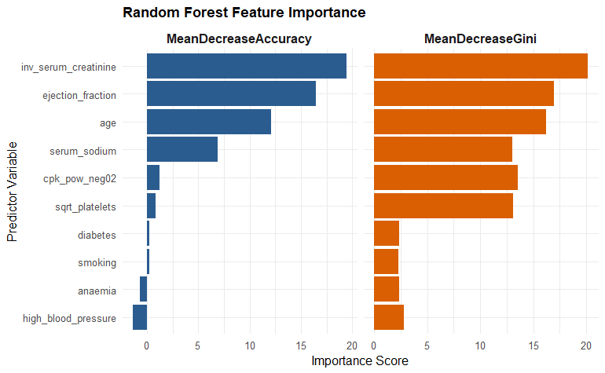

```r
#extract variable importance
var_imp <- as.data.frame(randomForest::importance(rf_fit))
var_imp$Variable <- rownames(var_imp)

#plot mean decrease accuracy & mean decrease gini
var_imp_long <- var_imp %>%
  tidyr::pivot_longer(cols = c("MeanDecreaseAccuracy", "MeanDecreaseGini"),
                      names_to = "Metric", values_to = "Importance")

ggplot2::ggplot(var_imp_long, aes(x = reorder(Variable, Importance), y = Importance, fill = Metric)) +
  geom_col(show.legend = FALSE) +
  coord_flip() +
  facet_wrap(~ Metric, scales = "free_x") +
  scale_fill_manual(values = c("MeanDecreaseAccuracy" = "#2b5c8f", "MeanDecreaseGini" = "#d95f02")) +
  labs(
    title = "Random Forest Feature Importance",
    x = "Predictor Variable",
    y = "Importance Score"
  ) +
  theme_minimal(base_size = 11) +
  theme(
    strip.text = element_text(face = "bold", size = 11),
    plot.title = element_text(face = "bold", size = 12)
  )
```

#XGBoosting

```r
library(xgboost)
library(caret)
library(pROC)
library(dplyr)
library(tibble)

#define complete feature matrix (6 transformed continuous + 4 binary predictors)
features <- c("age", "cpk_pow_neg02", "ejection_fraction",
              "sqrt_platelets", "inv_serum_creatinine", "serum_sodium",
              "high_blood_pressure", "anaemia", "diabetes", "smoking")

X_train <- as.matrix(train_df[, features])
y_train <- train_df$DEATH_EVENT

X_test  <- as.matrix(test_df[, features])
y_test  <- test_df$DEATH_EVENT

#convert to dmatrix format
dtrain <- xgb.DMatrix(data = X_train, label = y_train)
dtest  <- xgb.DMatrix(data = X_test, label = y_test)

# 3. Calculate class imbalance weight ratio: (negative cases / positive cases)
scale_pos_weight_val <- sum(y_train == 0) / sum(y_train == 1)
cat("Class Imbalance Ratio (scale_pos_weight):", round(scale_pos_weight_val, 2), "\n")
```

```
Class Imbalance Ratio (scale_pos_weight): 2.04
```

```r
set.seed(42)

#define hyperparameter grid
hyper_grid <- expand.grid(
  max_depth = c(2, 3, 4),
  eta = c(0.01, 0.05, 0.1),
  subsample = c(0.7, 0.8, 1.0),
  colsample_bytree = c(0.7, 0.8, 1.0),
  best_nrounds = 0,
  test_auc = 0
)

#robust cross validation loop
for(i in 1:nrow(hyper_grid)) {
  params <- list(
    booster          = "gbtree",
    objective        = "binary:logistic",
    eval_metric      = "auc",
    max_depth        = hyper_grid$max_depth[i],
    eta              = hyper_grid$eta[i],
    subsample        = hyper_grid$subsample[i],
    colsample_bytree = hyper_grid$colsample_bytree[i],
    scale_pos_weight = scale_pos_weight_val
  )

  xgb_cv <- xgb.cv(
    params                = params,
    data                  = dtrain,
    nrounds               = 300,
    nfold                 = 5,
    early_stopping_rounds = 30,
    verbose               = FALSE,
    stratified            = TRUE
  )

  #safeguard against NULL best_iteration if early stopping isn't triggered
  best_iter <- ifelse(is.null(xgb_cv$best_iteration), 300, xgb_cv$best_iteration)

  hyper_grid$best_nrounds[i] <- best_iter
  hyper_grid$test_auc[i]     <- max(xgb_cv$evaluation_log$test_auc_mean)
}

#select best performing parameters
best_params <- hyper_grid[which.max(hyper_grid$test_auc), ]
cat("=== OPTIMAL XGBOOST HYPERPARAMETERS ===\n")
```

```
=== OPTIMAL XGBOOST HYPERPARAMETERS ===
```

```r
print(best_params)
```

```
   max_depth eta subsample colsample_bytree best_nrounds  test_auc
61         2 0.1       0.7                1          300 0.8256557
```

```r
#fit final model on full training set using optimal hyperparameters
final_params <- list(
  booster          = "gbtree",
  objective        = "binary:logistic",
  eval_metric      = "auc",
  max_depth        = best_params$max_depth,
  eta              = best_params$eta,
  subsample        = best_params$subsample,
  colsample_bytree = best_params$colsample_bytree,
  scale_pos_weight = scale_pos_weight_val
)

xgb_fit <- xgb.train(
  params  = final_params,
  data    = dtrain,
  nrounds = best_params$best_nrounds
)

#predict probabilities on test set
test_xgb_probs <- predict(xgb_fit, dtest)

#roc and optimal threshold (youden's j)
roc_xgb <- pROC::roc(y_test, test_xgb_probs, quiet = TRUE)
opt_thresh_xgb <- pROC::coords(roc_xgb, "best", best.method = "youden")$threshold

#performance function (calculates MCC directly from the confusion matrix)
get_xgb_metrics <- function(probs, actual, threshold, label) {
  preds <- ifelse(probs >= threshold, 1, 0)
  cm <- caret::confusionMatrix(
    factor(preds, levels = c(0, 1)),
    factor(actual, levels = c(0, 1)),
    positive = "1"
  )

  #extract confusion matrix components for MCC
  TP <- cm$table["1", "1"]
  TN <- cm$table["0", "0"]
  FP <- cm$table["1", "0"]
  FN <- cm$table["0", "1"]

  num <- (TP * TN) - (FP * FN)
  den <- sqrt(as.numeric(TP + FP) * as.numeric(TP + FN) *
              as.numeric(TN + FP) * as.numeric(TN + FN))

  mcc_val <- ifelse(den == 0, 0, num / den)

  tibble::tibble(
    Model            = "XGBoost",
    Approach         = label,
    Threshold        = round(threshold, 4),
    Sensitivity      = round(cm$byClass["Sensitivity"], 4),
    Specificity      = round(cm$byClass["Specificity"], 4),
    MCC              = round(mcc_val, 4),
    Overall_Accuracy = round(cm$overall["Accuracy"], 4),
    ROC_AUC          = round(pROC::auc(roc_xgb), 4)
  )
}

xgb_results <- dplyr::bind_rows(
  get_xgb_metrics(test_xgb_probs, y_test, 0.5000, "1. Baseline (p = 0.50)"),
  get_xgb_metrics(test_xgb_probs, y_test, opt_thresh_xgb, "2. Youden J Threshold")
)

cat("=== XGBOOST TEST PERFORMANCE ===\n")
```

```
=== XGBOOST TEST PERFORMANCE ===
```

```r
print(as.data.frame(xgb_results))
```

```
    Model               Approach Threshold Sensitivity Specificity    MCC Overall_Accuracy ROC_AUC
1 XGBoost 1. Baseline (p = 0.50)    0.5000      0.5294      0.7619 0.2824           0.6949  0.6415
2 XGBoost  2. Youden J Threshold    0.3137      0.6471      0.7143 0.3355           0.6949  0.6415
```

```r
library(MVN)
useful_vars <- c("age", "ejection_fraction", "inv_serum_creatinine", "serum_sodium")
X_cont <- train_df[, useful_vars]
# 1. Henze-Zirkler Test
hz_result <- mvn(data = X_cont)
summary(hz_result)
```

```
           Test Statistic p.value     Method          MVN
1 Henze-Zirkler     1.789  <0.001 asymptotic ✗ Not normal
              Test             Variable Statistic p.value    Normality
1 Anderson-Darling                  age     1.358   0.002 ✗ Not normal
2 Anderson-Darling    ejection_fraction     4.933  <0.001 ✗ Not normal
3 Anderson-Darling inv_serum_creatinine     1.906  <0.001 ✗ Not normal
4 Anderson-Darling         serum_sodium     2.690  <0.001 ✗ Not normal
              Variable   n    Mean Std.Dev  Median     Min     Max    25th   75th   Skew Kurtosis
1                  age 240  61.572  11.913  60.000  40.000  95.000  52.750  70.00  0.415    2.846
2    ejection_fraction 240  37.829  11.694  38.000  14.000  80.000  30.000  41.25  0.622    3.308
3 inv_serum_creatinine 240   0.862   0.306   0.909   0.106   1.667   0.667   1.00 -0.188    2.884
4         serum_sodium 240 136.375   4.573 137.000 113.000 146.000 134.000 139.00 -1.140    6.958
```

#Multivariate Outlier Analysis anad Model Sensitivy Check

```r
library(dplyr)
library(ggplot2)
library(pROC)
library(caret)
library(randomForest)
library(xgboost)
library(tibble)

# ==============================================================================
# 1. DEFINE CONTINUOUS FEATURE MATRIX & MAHALANOBIS DISTANCE
# ==============================================================================
cont_vars <- c("age", "cpk_pow_neg02", "ejection_fraction",
               "sqrt_platelets", "inv_serum_creatinine", "serum_sodium")

X_cont <- train_df[, cont_vars]

# Compute Mean Vector and Covariance Matrix
center_vec <- colMeans(X_cont)
cov_mat    <- cov(X_cont)

# Calculate Mahalanobis Distance for each observation
m_dist <- mahalanobis(X_cont, center = center_vec, cov = cov_mat)

# Critical Value Threshold (Chi-Square with df = 6, alpha = 0.01)
p_val <- 0.01
critical_val <- qchisq(1 - p_val, df = length(cont_vars))

# Add results to dataframe
train_df_outliers <- train_df %>%
  dplyr::mutate(
    mahal_dist = m_dist,
    is_outlier = m_dist > critical_val,
    p_value    = pchisq(m_dist, df = length(cont_vars), lower.tail = FALSE)
  )

num_outliers <- sum(train_df_outliers$is_outlier)
cat("=== MULTIVARIATE OUTLIER DETECTION (MAHALANOBIS DISTANCE) ===\n")
```

```
=== MULTIVARIATE OUTLIER DETECTION (MAHALANOBIS DISTANCE) ===
```

```r
cat("Degrees of Freedom          :", length(cont_vars), "\n")
```

```
Degrees of Freedom          : 6
```

```r
cat("Critical Threshold (p=0.01):", round(critical_val, 3), "\n")
```

```
Critical Threshold (p=0.01): 16.812
```

```r
cat("Multivariate Outliers      :", num_outliers, "(", round(num_outliers / nrow(train_df) * 100, 2), "% of training data)\n\n")
```

```
Multivariate Outliers      : 7 ( 2.92 % of training data)
```

```r
# Display detected multivariate outliers
if(num_outliers > 0) {
  print(train_df_outliers %>%
          dplyr::filter(is_outlier) %>%
          dplyr::select(DEATH_EVENT, mahal_dist, p_value, inv_serum_creatinine, ejection_fraction, age))
}
```

```
# A tibble: 7 × 6
  DEATH_EVENT mahal_dist   p_value inv_serum_creatinine ejection_fraction   age
        <dbl>      <dbl>     <dbl>                <dbl>             <dbl> <dbl>
1           1       21.3 0.00160                  0.370                20    65
2           1       24.6 0.000410                 0.526                55    48
3           1       22.3 0.00106                  0.147                62    60
4           0       16.9 0.00965                  0.847                80    45
5           0       25.3 0.000297                 0.769                35    45
6           0       29.4 0.0000518                0.556                35    60
7           1       19.7 0.00316                  0.111                70    54
```

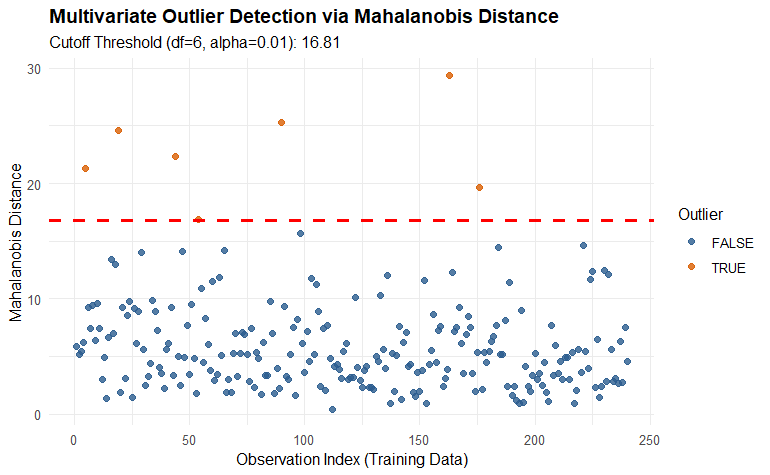

```r
# ==============================================================================
# 2. VISUALIZE MAHALANOBIS DISTANCE DISTRIBUTION
# ==============================================================================
ggplot(train_df_outliers, aes(x = seq_along(mahal_dist), y = mahal_dist, color = is_outlier)) +
  geom_point(size = 2, alpha = 0.8) +
  geom_hline(yintercept = critical_val, linetype = "dashed", color = "red", linewidth = 1) +
  scale_color_manual(values = c("FALSE" = "#2b5c8f", "TRUE" = "#d95f02")) +
  labs(
    title = "Multivariate Outlier Detection via Mahalanobis Distance",
    subtitle = paste0("Cutoff Threshold (df=6, alpha=0.01): ", round(critical_val, 2)),
    x = "Observation Index (Training Data)",
    y = "Mahalanobis Distance",
    color = "Outlier"
  ) +
  theme_minimal(base_size = 11) +
  theme(plot.title = element_text(face = "bold"))
```

```r
# ==============================================================================
# 3. CREATE CLEAN TRAINING DATASET
# ==============================================================================
train_df_clean <- train_df_outliers %>% dplyr::filter(!is_outlier)

# ==============================================================================
# 4. REFIT ALL 4 MODELS ON CLEAN TRAINING DATA
# ==============================================================================

# --- A. BIC MODEL (CLEAN) ---
bic_clean_model <- glm(
  DEATH_EVENT ~ inv_serum_creatinine + age + ejection_fraction,
  data = train_df_clean,
  family = binomial(link = "logit")
)

# --- B. AIC MODEL (CLEAN) ---
aic_clean_model <- glm(
  DEATH_EVENT ~ inv_serum_creatinine + age + ejection_fraction +
                high_blood_pressure + inv_serum_creatinine:ejection_fraction +
                age:ejection_fraction,
  data = train_df_clean,
  family = binomial(link = "logit")
)

# --- C. RANDOM FOREST (CLEAN) ---
# Prepare clean dataset for Random Forest (factor outcome required)
train_df_rf_clean <- train_df_clean
train_df_rf_clean$DEATH_EVENT <- factor(ifelse(train_df_clean$DEATH_EVENT == 1, "Died", "Survived"),
                                       levels = c("Survived", "Died"))

set.seed(42)
rf_clean_fit <- randomForest(
  DEATH_EVENT ~ age + cpk_pow_neg02 + ejection_fraction + sqrt_platelets +
                inv_serum_creatinine + serum_sodium + high_blood_pressure +
                anaemia + diabetes + smoking,
  data = train_df_rf_clean,
  ntree = 500,
  importance = TRUE
)

# --- D. XGBOOST (CLEAN) ---
features <- c("age", "cpk_pow_neg02", "ejection_fraction",
              "sqrt_platelets", "inv_serum_creatinine", "serum_sodium",
              "high_blood_pressure", "anaemia", "diabetes", "smoking")

X_train_clean <- as.matrix(train_df_clean[, features])
y_train_clean <- train_df_clean$DEATH_EVENT
dtrain_clean  <- xgb.DMatrix(data = X_train_clean, label = y_train_clean)

scale_pos_weight_clean <- sum(y_train_clean == 0) / sum(y_train_clean == 1)

final_params_clean <- list(
  booster          = "gbtree",
  objective        = "binary:logistic",
  eval_metric      = "auc",
  max_depth        = best_params$max_depth,
  eta              = best_params$eta,
  subsample        = best_params$subsample,
  colsample_bytree = best_params$colsample_bytree,
  scale_pos_weight = scale_pos_weight_clean
)

set.seed(42)
xgb_clean_fit <- xgb.train(
  params  = final_params_clean,
  data    = dtrain_clean,
  nrounds = best_params$best_nrounds
)

# ==============================================================================
# 5. COEFFICIENT COMPARISONS (GLM MODELS)
# ==============================================================================
cat("\n=== CHAMPION BIC MODEL (FULL TRAINING DATA) ===\n")
```

```
=== CHAMPION BIC MODEL (FULL TRAINING DATA) ===
```

```r
print(summary(best_model_bic)$coefficients)
```

```
                        Estimate Std. Error     z value     Pr(>|z|)
(Intercept)           0.03788877 1.07754831  0.03516201 9.719506e-01
inv_serum_creatinine -2.67927434 0.56985188 -4.70170311 2.580004e-06
age                   0.05038388 0.01386893  3.63285870 2.802985e-04
ejection_fraction    -0.04661357 0.01483102 -3.14297726 1.672388e-03
```

```r
cat("\n=== CHAMPION BIC MODEL (REMOVED MULTIVARIATE OUTLIERS) ===\n")
```

```
=== CHAMPION BIC MODEL (REMOVED MULTIVARIATE OUTLIERS) ===
```

```r
print(summary(bic_clean_model)$coefficients)
```

```
                        Estimate Std. Error    z value     Pr(>|z|)
(Intercept)          -0.24273861 1.10164261 -0.2203424 8.256045e-01
inv_serum_creatinine -2.24752451 0.58480984 -3.8431715 1.214545e-04
age                   0.05749487 0.01453594  3.9553586 7.641994e-05
ejection_fraction    -0.06248068 0.01695713 -3.6846255 2.290392e-04
```

```r
cat("\n======================================================================\n")
cat("\n=== AIC MODEL (FULL TRAINING DATA) ===\n")
```

```
=== AIC MODEL (FULL TRAINING DATA) ===
```

```r
print(summary(best_model_aic)$coefficients)
```

```
                                           Estimate  Std. Error    z value   Pr(>|z|)
(Intercept)                             3.579221949 3.723553418  0.9612382 0.33643239
inv_serum_creatinine                    0.639267881 1.880753020  0.3399000 0.73393186
age                                    -0.045574421 0.053845713 -0.8463890 0.39733576
ejection_fraction                      -0.154443818 0.099492267 -1.5523198 0.12058572
high_blood_pressure                     0.771972742 0.352131077  2.1922880 0.02835872
inv_serum_creatinine:ejection_fraction -0.099397831 0.051102301 -1.9450754 0.05176590
age:ejection_fraction                   0.002763429 0.001466279  1.8846535 0.05947663
```

```r
cat("\n=== AIC MODEL (REMOVED MULTIVARIATE OUTLIERS) ===\n")
```

```
=== AIC MODEL (REMOVED MULTIVARIATE OUTLIERS) ===
```

```r
print(summary(aic_clean_model)$coefficients)
```

```
                                           Estimate  Std. Error    z value    Pr(>|z|)
(Intercept)                             9.649258707 4.742958389  2.0344388 0.041907370
inv_serum_creatinine                   -2.121029217 2.437426322 -0.8701921 0.384195413
age                                    -0.099195991 0.059354547 -1.6712450 0.094673288
ejection_fraction                      -0.349635171 0.134538417 -2.5987757 0.009355688
high_blood_pressure                     0.759716038 0.361480490  2.1016792 0.035581384
inv_serum_creatinine:ejection_fraction -0.008964556 0.069479756 -0.1290240 0.897338664
age:ejection_fraction                   0.004440655 0.001649467  2.6921763 0.007098740
```

```r
# ==============================================================================
# 6. HELPER EVALUATION FUNCTION WITH MCC (YOUDEN'S J OPTIMIZATION)
# ==============================================================================
eval_sens_model <- function(probs, actual, label) {
  roc_obj    <- pROC::roc(actual, probs, quiet = TRUE)
  opt_thresh <- pROC::coords(roc_obj, "best", best.method = "youden")$threshold
  preds      <- ifelse(probs >= opt_thresh, 1, 0)

  cm <- caret::confusionMatrix(
    factor(preds, levels = c(0, 1)),
    factor(actual, levels = c(0, 1)),
    positive = "1"
  )

  # Calculate MCC directly from confusion matrix
  TP <- cm$table["1", "1"]
  TN <- cm$table["0", "0"]
  FP <- cm$table["1", "0"]
  FN <- cm$table["0", "1"]

  num <- (TP * TN) - (FP * FN)
  den <- sqrt(as.numeric(TP + FP) * as.numeric(TP + FN) *
              as.numeric(TN + FP) * as.numeric(TN + FN))

  mcc_val <- ifelse(den == 0, 0, num / den)

  tibble::tibble(
    Model            = label,
    Threshold        = round(opt_thresh, 4),
    ROC_AUC          = round(pROC::auc(roc_obj), 4),
    Sensitivity      = round(cm$byClass["Sensitivity"], 4),
    Specificity      = round(cm$byClass["Specificity"], 4),
    MCC              = round(mcc_val, 4),
    Overall_Accuracy = round(cm$overall["Accuracy"], 4)
  )
}

# ==============================================================================
# 7. GENERATE TEST SET PREDICTIONS FOR ALL FULL & CLEAN MODELS
# ==============================================================================
probs_bic_full  <- predict(best_model_bic, newdata = test_df, type = "response")
probs_bic_clean <- predict(bic_clean_model, newdata = test_df, type = "response")

probs_aic_full  <- predict(best_model_aic, newdata = test_df, type = "response")
probs_aic_clean <- predict(aic_clean_model, newdata = test_df, type = "response")

probs_rf_full   <- predict(rf_fit, newdata = test_df_rf, type = "prob")[, "Died"]
probs_rf_clean  <- predict(rf_clean_fit, newdata = test_df_rf, type = "prob")[, "Died"]

X_test_mat      <- as.matrix(test_df[, features])
dtest_mat       <- xgb.DMatrix(data = X_test_mat)
probs_xgb_full  <- predict(xgb_fit, dtest_mat)
probs_xgb_clean <- predict(xgb_clean_fit, dtest_mat)

# ==============================================================================
# 8. SENSITIVITY ANALYSIS PERFORMANCE COMPARISON TABLE
# ==============================================================================
sens_summary <- dplyr::bind_rows(
  eval_sens_model(probs_bic_full,  test_df$DEATH_EVENT, "1. BIC Model (Full Data)"),
  eval_sens_model(probs_bic_clean, test_df$DEATH_EVENT, "2. BIC Model (Cleaned)"),
  eval_sens_model(probs_aic_full,  test_df$DEATH_EVENT, "3. AIC Model (Full Data)"),
  eval_sens_model(probs_aic_clean, test_df$DEATH_EVENT, "4. AIC Model (Cleaned)"),
  eval_sens_model(probs_rf_full,   test_df$DEATH_EVENT, "5. Random Forest (Full Data)"),
  eval_sens_model(probs_rf_clean,  test_df$DEATH_EVENT, "6. Random Forest (Cleaned)"),
  eval_sens_model(probs_xgb_full,  test_df$DEATH_EVENT, "7. XGBoost Benchmark (Full Data)"),
  eval_sens_model(probs_xgb_clean, test_df$DEATH_EVENT, "8. XGBoost Benchmark (Cleaned)")
)

cat("\n=== SENSITIVITY ANALYSIS PERFORMANCE COMPARISON (TEST SET) ===\n")
```

```
=== SENSITIVITY ANALYSIS PERFORMANCE COMPARISON (TEST SET) ===
```

```r
print(as.data.frame(sens_summary))
```

```
                             Model Threshold ROC_AUC Sensitivity Specificity    MCC Overall_Accuracy
1         1. BIC Model (Full Data)    0.2240  0.7563      0.8235      0.6905 0.4673           0.7288
2           2. BIC Model (Cleaned)    0.2511  0.7731      0.8235      0.7619 0.5397           0.7797
3         3. AIC Model (Full Data)    0.2125  0.7661      0.8235      0.6667 0.4446           0.7119
4           4. AIC Model (Cleaned)    0.3265  0.7605      0.7059      0.7619 0.4381           0.7458
5     5. Random Forest (Full Data)    0.3060  0.7108      0.7059      0.7381 0.4123           0.7288
6       6. Random Forest (Cleaned)    0.3560  0.7150      0.7059      0.7857 0.4650           0.7627
7 7. XGBoost Benchmark (Full Data)    0.3137  0.6415      0.6471      0.7143 0.3355           0.6949
8   8. XGBoost Benchmark (Cleaned)    0.1718  0.6471      0.7059      0.6429 0.3170           0.6610
```